# COVID-19 vaccine effectiveness against in-hospital mortality in immunocompromised older adults: a Brazilian hospital surveillance study, 2024

# Preparing data

Load libraries:

```r
library(openxlsx)
library(dplyr)
library(lubridate)
library(purrr)
library(tidyr)
library(prettyR)
library(scales)
library(DescTools)
```

```r
library(ggplot2)
library(pROC)
library(ResourceSelection)
```

```
## ResourceSelection 0.3-6   2023-06-27
```

```r
compareNA <- function(v1,v2) {
    same <- (v1 == v2) | (is.na(v1) & is.na(v2))
    same[is.na(same)] <- FALSE
    return(same)
}
```

Load SIVEP-Gripe data:

```r
df <- read.xlsx("SRAG 2024_DOWNLOAD 29_3_25 IMUNODEPRE_RT_PCR OU ANTIGENO POSITIVO.xlsx", detectDates = TRUE)
```

It has 1436 patients before filtering.

## Filtering population

```r
filtered <- df %>%
  filter(
    NOSOCOMIAL == 2,                         # Non-nosocomial
    NU_IDADE_N >= 60,                        # 60 years old or older
    IMUNODEPRE == 1,                         # Immunosuppressed
    HOSPITAL == 1,                           # Hospitalized
    !is.na(DT_INTERNA),                      # With hospitalization date
    CLASSI_FIN == 5,                         # With COVID classification
    PCR_SARS2 == 1 | AN_SARS2 == 1,          # With positive COVID test
    EVOLUCAO %in% c(1, 2),                   # Survival or death (not other causes)
    DT_EVOLUCA >= ymd("2023-12-31"),         # Start of epidemiological year
    DT_EVOLUCA <= ymd("2024-12-28")          # End of epidemiological year
  )
```

After the population filter, it had 474 patients.

## Data cleaning and preparing

### Days since the beginning of the infection

```r
# D: DIAS INICIO SIN HOSPITALIZAÇÃO
filtered <- filtered %>%
  mutate(delta_days = as.numeric(DT_INTERNA - DT_SIN_PRI))

#stopifnot(all(compareNA(filtered$"DIAS.INICIO.SIN.HOSPITALIZA<U+00C7><U+00C3>O", filtered$delta_days)))
```

### Additional risk commorbidities

```r
# AR: COMORBIDADES ADICIONAIS
filtered <- filtered %>%
  mutate(additional_risk_comorbidities =
           as.integer(replace_na(CARDIOPATI, 0) == 1) +
           as.integer(replace_na(HEMATOLOGI, 0) == 1) +
           as.integer(replace_na(SIND_DOWN, 0) == 1) +
           as.integer(replace_na(HEPATICA, 0) == 1) +
           as.integer((replace_na(ASMA, 0) == 1) | (replace_na(PNEUMOPATI, 0) == 1)) +
           as.integer(replace_na(DIABETES, 0) == 1) +
           as.integer(replace_na(NEUROLOGIC, 0) == 1) +
           as.integer(replace_na(RENAL, 0) == 1) +
           as.integer(replace_na(OBESIDADE, 0) == 1))


#stopifnot(all(compareNA(filtered$COMORBIDADES.ADICIONAIS, filtered$additional_risk_comorbidities)))
```

### Risk groups

```r
filtered <- filtered %>%
  mutate(
    risk_groups = case_when(
      additional_risk_comorbidities >= 2 ~ '2+',
      additional_risk_comorbidities == 1 ~ '1',
      TRUE ~ 'None'
    ),
    at_least_one_risk = case_when(
      additional_risk_comorbidities >= 1 ~ 1,
      TRUE ~ 0
    )
  )
```

### Dates of vaccines

```r
filtered <- filtered %>%
  mutate(
    dose_dates = pmap(
      list(
        DOSE_1_COV,
        DOSE_2_COV,
        DOSE_ADIC,
        DOSE_REF,
        DOSE_2REF,
        DOS_RE_BI
      ),
      ~ {
        doses <- as.Date(c(...))
        doses[!is.na(doses)]
      }
    )
  )
```

Column that only consider vaccines that have both the date of administration and the manufacturer.

```r
filtered <- filtered %>%
  mutate(dose_dates_with_fab = pmap(list(FAB_COV_1, DOSE_1_COV,
                               FAB_COV_2, DOSE_2_COV,
                               FAB_ADIC, DOSE_ADIC,
                               FAB_COVREF, DOSE_REF,
                               FAB_COVRF2, DOSE_2REF,
                               FAB_RE_BI, DOS_RE_BI),
                           ~ {
                             doses <- c(
                               as.Date(ifelse(!is.na(..1), ..2, NA)),
                               as.Date(ifelse(!is.na(..3), ..4, NA)),
                               as.Date(ifelse(!is.na(..5), ..6, NA)),
                               as.Date(ifelse(!is.na(..7), ..8, NA)),
                               as.Date(ifelse(!is.na(..9), ..10, NA)),
                               as.Date(ifelse(!is.na(..11), ..12, NA))
                             )
                             doses[!is.na(doses)]
                           })
  )
```

### Last vaccine date

```r
# Extract the last dose date (latest non-NA date in the list)
filtered <- filtered %>%
  mutate(last_date = map(dose_dates, ~ if (length(.x) == 0) NA else max(.x, na.rm = TRUE)))
```

### Days between vaccine date and internation

```r
# Calculate the number of days betwenn the vaccine date and internation
filtered <- filtered %>%
  mutate(days_since_last_vaccine = if_else(
      (length(last_date) == 0 || all(is.na(last_date))) | is.na(DT_INTERNA),
      NA,
      as.numeric(as.Date(DT_INTERNA, format = "%Y-%m-%d") - as.Date(map_dbl(filtered$last_date, 1)))
    ))

        #   as.numeric( - ))
```

### Intervals between vaccine date and internation

```r
filtered <- filtered %>%
  mutate(
    last_vaccine_interval = case_when(
      days_since_last_vaccine <= 183 ~ "up to 6 months",
      days_since_last_vaccine <= 365 ~ "7–12 months",
      days_since_last_vaccine > 365  ~ "over 1 year",
      TRUE ~ NA_character_
    )
  )
```

```r
filtered <- filtered %>%
  mutate(
    last_vaccine_interval_broader = case_when(
      days_since_last_vaccine <= 365 ~ "up to 1 year",
      days_since_last_vaccine > 365  ~ "over 1 year",
      TRUE ~ NA_character_
    )
  )
```

### Last vaccine year

```r
# Extract the year from the last_date
filtered <- filtered %>%
  mutate(last_year = map_dbl(last_date, ~ ifelse(is.na(.x), NA, year(.x))))

# Compute the minimum non-NA year
min_last_year <- min(filtered$last_year, na.rm = TRUE)

# Compute year range starting from 1
filtered <- filtered %>%
  mutate(last_year_range = ifelse(is.na(last_year), NA, last_year - min_last_year + 1))

#stopifnot(all(
#  compareNA(filtered$"ANO.DA.<U+00DA>LTIMA.DOSE.VAC_COV;.2021=1;.2022=2;.2023=3;.2024=4", filtered$last_year_range)
#))
```

### Number of doses

```r
# FF: N DOSES VAC_COV   (preenchendo em branco com 0)
filtered <- filtered %>%
  mutate(doses = map_int(dose_dates, length))

#stopifnot(all(compareNA(replace_na(filtered$N.DOSES.VAC_COV, 0), filtered$doses)))
```

### Number of doses groups

```r
filtered <- filtered %>%
  mutate(
    dose_groups = case_when(
      doses >= 3 ~ '3+',
      doses == 2 ~ '2',
      doses == 1 ~ '1',
      TRUE ~ '0'
    ),)
```

```r
filtered <- filtered %>%
  mutate(
    dose_completion_groups = case_when(
      doses >= 2 ~ '2+',
      TRUE ~ '0-1'
    ),)
```

### Types of vaccines

Define groups and check if the definition is complete

```r
# Define vaccine groups
innactivated_vaccines <- c(
  '86 - COVID-19 SINOVAC/BUTANTAN - CORONAVAC',
  'CORONAVAC',
  'SINOVAC',
  'SINOVAC/BUTANTAN',
  'SINOVAC/BUTANT',
  'INSTITUTO BUTANTAN'
)

viral_vector_vaccines <- c(
  '85 - COVID-19 ASTRAZENECA/FIOCRUZ - COVISHIELD',
  '89 - COVID-19 ASTRAZENECA - CHADOX1-S',
  'ASTRAZENECA AB',
  'ASTRAZENICA/FIOCRUZ',
  'FABRICANTE FUNDACAO OSWALDO CRUZ',
  '88 - COVID-19 JANSSEN - AD26.COV2.S',
  'JANSSEN',
  'JANSSEN PHARMACEUTICA NV'
)

mrna_vaccines <- c(
  '87 - COVID-19 PFIZER - COMIRNATY',
  'PFIZER',
  'PFIZER MANUFACTURING BELGIUM NV - BELGICA',
  'PFIZER/ BIVALENTE',
  '103 - COVID-19 PFIZER - COMIRNATY BIVALENTE'
)

mapped_vaccines <- c(innactivated_vaccines, viral_vector_vaccines, mrna_vaccines, '<vazio>')

# Now run assertions similar to Python
stopifnot(
  identical(setdiff(unique(replace_na(filtered$FAB_COV_1, '<vazio>')), mapped_vaccines), character(0))
)
stopifnot(
  identical(setdiff(unique(replace_na(filtered$FAB_COV_2, '<vazio>')), mapped_vaccines), character(0))
)
stopifnot(
  identical(setdiff(unique(replace_na(filtered$FAB_ADIC, '<vazio>')), mapped_vaccines), character(0))
)
stopifnot(
  identical(setdiff(unique(replace_na(filtered$FAB_COVREF, '<vazio>')), mapped_vaccines), character(0))
)
stopifnot(
  identical(setdiff(unique(replace_na(filtered$FAB_COVRF2, '<vazio>')), mapped_vaccines), character(0))
)
stopifnot(
  identical(setdiff(unique(replace_na(as.character(filtered$FAB_RE_BI), '<vazio>')), mapped_vaccines), character(0))
)
```

Create columns with the count of each valid dose given the type.

```r
filtered <- filtered %>%
  mutate(
    innactivated_doses = pmap_int(
      list(DOSE_1_COV, FAB_COV_1,
           DOSE_2_COV, FAB_COV_2,
           DOSE_ADIC, FAB_ADIC,
           DOSE_REF, FAB_COVREF,
           DOSE_2REF, FAB_COVRF2#,
           # DOS_RE_BI, FAB_RE_BI -- currently, all DOS_RE_BI are mrna vaccines
           ),
      ~ sum(
          (!is.na(..1) & ..2 %in% innactivated_vaccines),
          (!is.na(..3) & ..4 %in% innactivated_vaccines),
          (!is.na(..5) & ..6 %in% innactivated_vaccines),
          (!is.na(..7) & ..8 %in% innactivated_vaccines),
          (!is.na(..9) & ..10 %in% innactivated_vaccines)#,
          #(!is.na(..11) & ..12 %in% innactivated_vaccines)
        )
    ),
    viral_vector_doses = pmap_int(
      list(DOSE_1_COV, FAB_COV_1,
           DOSE_2_COV, FAB_COV_2,
           DOSE_ADIC, FAB_ADIC,
           DOSE_REF, FAB_COVREF,
           DOSE_2REF, FAB_COVRF2#,
           #DOS_RE_BI, FAB_RE_BI -- currently, all DOS_RE_BI are mrna vaccines
           ),
      ~ sum(
          (!is.na(..1) & ..2 %in% viral_vector_vaccines),
          (!is.na(..3) & ..4 %in% viral_vector_vaccines),
          (!is.na(..5) & ..6 %in% viral_vector_vaccines),
          (!is.na(..7) & ..8 %in% viral_vector_vaccines),
          (!is.na(..9) & ..10 %in% viral_vector_vaccines)#,
          #(!is.na(..11) & ..12 %in% viral_vector_vaccines)
        )
    ),
    mrna_doses = pmap_int(
      list(DOSE_1_COV, FAB_COV_1,
           DOSE_2_COV, FAB_COV_2,
           DOSE_ADIC, FAB_ADIC,
           DOSE_REF, FAB_COVREF,
           DOSE_2REF, FAB_COVRF2,
           DOS_RE_BI, FAB_RE_BI),
      ~ sum(
          (!is.na(..1) & ..2 %in% mrna_vaccines),
          (!is.na(..3) & ..4 %in% mrna_vaccines),
          (!is.na(..5) & ..6 %in% mrna_vaccines),
          (!is.na(..7) & ..8 %in% mrna_vaccines),
          (!is.na(..9) & ..10 %in% mrna_vaccines),
          (!is.na(..11)) # & ..12 %in% mrna_vaccines -- all DOS_RE_BI are MRNA vaccines. It does not need to check the FAB
        )
    )
  )
```

### Vaccination schema

inactivated=1; mRNA=2; viral vector=3; inactivated+ mRNA=4; inactivated + viral vector=5; mRNA+ viral vector=6; inactivated+ mRNA + viral vector=7.

```r
# FQ: Esquema vacinal: inativada=1; RNAm=2; vetor viral=3; inativada + RNAm=4; inativada + vetor viral=5; RNAm + vetor viral=6; inativada + RNAm + vetor viral=7
dose_df <- filtered %>%
  transmute(
    i = innactivated_doses,
    v = viral_vector_doses,
    m = mrna_doses
  )

# Apply the logic row-wise
vaccinal_schema <- pmap_int(dose_df, function(i, v, m) {
  if (i > 0 & v > 0 & m > 0) {
    7
  } else if (v > 0 & m > 0) {
    6
  } else if (v > 0 & i > 0) {
    5
  } else if (m > 0 & i > 0) {
    4
  } else if (v > 0) {
    3
  } else if (m > 0) {
    2
  } else if (i > 0) {
    1
  } else {
    0
  }
})

# Attach it back to the `filtered` dataframe
filtered <- filtered %>%
  mutate(
    vaccinal_schema = vaccinal_schema,
    nominal_vaccinal_schema = recode(
      vaccinal_schema,
      `0` = "None",
      `1` = "Inactivated only",
      `2` = "mRNA only",
      `3` = "Viral vector only",
      `4` = "Inactivated + mRNA",
      `5` = "Inactivated + Viral vector",
      `6` = "mRNA + viral vector",
      `7` = "Inactivated + mRNA + viral vector"
    ),
    vaccinal_schema_count = recode(
      vaccinal_schema,
      `0` = 0,
      `1` = 1,
      `2` = 1,
      `3` = 1,
      `4` = 2,
      `5` = 2,
      `6` = 2,
      `7` = 3
      )
  )

#stopifnot(all(
#  compareNA(replace_na(filtered$`Esquema.vacinal:.inativada=1;.RNAm=2;.vetor.viral=3;.inativada.+.RNAm=4;.inativada.+.vetor.viral=5;.RNAm.+.vetor.viral=6;.inativada.+.RNAm.+.vetor.viral=7`, 0), vaccinal_schema)
#))
```

Schema based on inactivated

```r
filtered <- filtered %>%
  mutate(
    vaccinal_schema_based_on_innactivated = pmap_chr(list(innactivated_doses, viral_vector_doses, mrna_doses), function(i, v, m) {
      if (i + v + m <= 1) {
        return('unvaccinated or single-dose')
      } else if (v == 0 & m == 0) {
        return('sequential with inactivated only')
      } else if (i == 0) {
        return('sequential excluding inactivated')
      } else {
        return('sequential with inactivated and others')
      }
    })
  )
```

### Age groups

```r
filtered <- filtered %>%
  mutate(
    age_groups = case_when(
      NU_IDADE_N >= 80 ~ '80+',
      NU_IDADE_N >= 70 ~ '70-79',
      TRUE ~ '60-69'
    )
  )
```

### Race groups

```r
filtered <- filtered %>%
  mutate(
    nominal_race = recode(
      filtered$CS_RACA,
      `1` = "White",
      `2` = "Black",
      `3` = "Yellow",
      `4` = "Brown",
      `5` = "Indigenous",
      `9` = "Unknown"
    )
  )
```

### Educational groups

```r
filtered <- filtered %>%
  mutate(
    educational_attainment = case_when(
      CS_ESCOL_N == 4 ~ 'bachelor',
      CS_ESCOL_N < 4 ~ 'low',
      TRUE ~ 'unknown'
    )
  )
```

```r
filtered <- filtered %>%
  mutate(
    nominal_education = replace_na(recode(
      filtered$CS_ESCOL_N,
      `0` = "Elementary",
      `1` = "Elementary",
      `2` = "Middle",
      `3` = "Highschool",
      `4` = "Bachelors",
      `5` = "Unknown",
      `9` = "Unknown"
    ), "Unknown")
  )
```

```r
filtered <- filtered %>%
  mutate(
    education_level = replace_na(recode(
      filtered$CS_ESCOL_N,
      `0` = "Elementary", # Elementary
      `1` = "Elementary", # Elementary
      `2` = "Middle", # Middle
      `3` = "High", # Highschool
      `4` = "High", # Bachelors
      `5` = "Unknown",
      `9` = "Unknown"
    ), "Unknown")
  )
```

### Dose groups

```r
filtered <- filtered %>%
  mutate(
    categorical_doses = case_when(
      doses >= 5 ~ '5+',
      doses == 4 ~ '4',
      doses == 3 ~ '3',
      doses >= 1 ~ '1-2',
      TRUE ~ 'unvaccinated'
    )
  )
```

### ICU admission

```r
filtered <- filtered %>%
  mutate(
    icu_admission = replace_na(recode(UTI, `1` = 1, `2` = 2, `9` = 2, .default = 2), 2),
    nominal_icu_admission = replace_na(recode(UTI, `1` = "Yes", `2` = "No", `9` = "No", .default = "No"), "No")
  )
```

### Invasive support ventilation

```r
filtered <- filtered %>%
  mutate(
    invasive_support_ven = replace_na(recode(SUPORT_VEN, `1` = 1, `3` = 2, `9` = 2, .default = 2), 2),
    nominal_invasive_support_ven = replace_na(recode(SUPORT_VEN, `1` = "Yes", `3` = "No", `9` = "No", .default = "No"), "No")
  )
```

### COVID treatment

```r
filtered <- filtered %>%
  mutate(
    covid_treatment = case_when(
      ((TRAT_COV == 1) & !is.na(TIPO_TRAT)) ~ 1,
      ((TRAT_COV > 1) & !is.na(TIPO_TRAT)) ~ 2,
      TRUE ~ 2
    ),
    nominal_covid_treatment = replace_na(recode(covid_treatment, `1` = "Yes", `9` = "No", .default = "No"), "No")
  )
```

### Split by outcome

```r
filtered <- filtered %>%
  mutate(
    nominal_outcome = recode(filtered$EVOLUCAO, `1` = "Survivor", `2` = "Non-survivor"),
    outcome = ifelse(filtered$EVOLUCAO == 1, 1, 0)
  )

survivors <- filtered %>%
  filter(EVOLUCAO == 1)
nonsurvivors <- filtered %>%
  filter(EVOLUCAO == 2)
```

## Create test spreadsheet

```r
test_dataframe <- filtered %>%
  mutate(
    `Outcome: Survivor = 1; Non-survivor = 2` = EVOLUCAO,
    `Sex: female = 1; male = 2` = recode(CS_SEXO, `F` = 1, `M` = 2),
    `ICU admission: yes = 1; no = 2` = icu_admission,
    `Invasive ventilatory support: yes =1; no =2` = invasive_support_ven,
    `Age group: 60-69 years = 1; 70-79 years =2; 80 years or older = 3` = recode(age_groups, `60-69` = 1, `70-79` = 2, `80+` = 3),
    `Educational attainment: low (up to high school); high (Bachelor) = 2; unknown = 9` = recode(educational_attainment, `low` = 1, `bachelor` = 2, `unknown` = 9),
    `Number of other risk conditions: none = 0; one or more = 1` = if_else(additional_risk_comorbidities >= 1, 1, 0),
    `COVID-19 vaccine doses: Unvaccinated = 0; one to two doses = 1; 3 doses = 2; 4 or more doses = 3` = recode(categorical_doses, `unvaccinated` = 0, `1-2` = 1, `3` = 2, `4` = 3, `5+` = 4),
    ` ` = NA_real_,
    `Esquemas de vacinação: unvaccinated or single-dose (reference): 1; sequential with inactivated only: 2; sequential excluding inactivated: 3; sequential with inactivated and others: 4` = recode(vaccinal_schema_based_on_innactivated,
                                                                                                                                          `unvaccinated or single-dose` = 1,
                                                                                                                                          `sequential with inactivated only` = 2,
                                                                                                                                          `sequential excluding inactivated` = 3,
                                                                                                                                          `sequential with inactivated and others` = 4)
  ) %>%
  select(
    `Outcome: Survivor = 1; Non-survivor = 2`,
    `Sex: female = 1; male = 2`,
    `ICU admission: yes = 1; no = 2`,
    `Invasive ventilatory support: yes =1; no =2`,
    `Age group: 60-69 years = 1; 70-79 years =2; 80 years or older = 3`,
    `Educational attainment: low (up to high school); high (Bachelor) = 2; unknown = 9`,
    `Number of other risk conditions: none = 0; one or more = 1`,
    `COVID-19 vaccine doses: Unvaccinated = 0; one to two doses = 1; 3 doses = 2; 4 or more doses = 3`,
    ` `,
    `Esquemas de vacinação: unvaccinated or single-dose (reference): 1; sequential with inactivated only: 2; sequential excluding inactivated: 3; sequential with inactivated and others: 4`
  )
```

Create `test.xlsx` file

```r
write.xlsx(test_dataframe, "test.xlsx")
```

## Set references

```r
filtered$outcome <- relevel(factor(filtered$outcome), ref="1")
filtered$age_groups <- relevel(factor(filtered$age_groups), ref = "60-69")
filtered$CS_SEXO <- relevel(factor(filtered$CS_SEXO), ref = "F")
filtered$nominal_race <- relevel(factor(filtered$nominal_race), ref="White")
filtered$nominal_icu_admission <- factor(filtered$nominal_icu_admission)
filtered$nominal_invasive_support_ven <- factor(filtered$nominal_invasive_support_ven)
filtered$educational_attainment <- relevel(factor(filtered$educational_attainment), ref="bachelor")
filtered$nominal_education <- relevel(factor(filtered$nominal_education), ref = "Bachelors")
filtered$education_level <- relevel(factor(filtered$education_level), ref = "High")
filtered$at_least_one_risk <- factor(filtered$at_least_one_risk)
filtered$risk_groups <- relevel(factor(filtered$risk_groups), ref="None")
filtered$categorical_doses <- relevel(factor(filtered$categorical_doses), ref="unvaccinated")
filtered$factor_doses <- relevel(factor(filtered$doses), ref=1)
filtered$nominal_vaccinal_schema <- relevel(factor(filtered$nominal_vaccinal_schema), ref="None")
filtered$nominal_covid_treatment <- relevel(factor(filtered$nominal_covid_treatment), ref="No")
filtered$education_level <- relevel(factor(filtered$education_level), ref = "High")
filtered$ndoses <- relevel(factor(filtered$doses), ref = "0")
filtered$last_year <- relevel(factor(filtered$last_year), ref = "2021")
filtered$last_vaccine_interval <- relevel(factor(filtered$last_vaccine_interval), ref = "over 1 year")
filtered$last_vaccine_interval_broader <- relevel(factor(filtered$last_vaccine_interval_broader), ref = "over 1 year")
```

## Population characterization

In total, 474 immunocompromised older adults hospitalized for COVID-19 in Brazil during the 2024 epidemiologic year were included in the analysis.

### Age

Median, min, max

```r
print(median(filtered$NU_IDADE_N))
```

```
## [1] 75
```

```r
print(min(filtered$NU_IDADE_N))
```

```
## [1] 60
```

```r
print(max(filtered$NU_IDADE_N))
```

```
## [1] 101
```

### Sex

```r
describe.factor(filtered$CS_SEXO)
```

```
##
## filtered$CS_SEXO         F         M
##          Count   252.00000 222.00000
##          Percent  53.16456  46.83544
```

### Race

```r
describe.factor(filtered$nominal_race)
```

```
##
## filtered$nominal_race     White    Brown  Unknown     Black    Yellow
##               Count   311.00000 97.00000 52.00000 10.000000 4.0000000
##               Percent  65.61181 20.46414 10.97046  2.109705 0.8438819
```

### Education

```r
describe.factor(filtered$educational_attainment)
```

```
##
## filtered$educational_attainment   unknown       low  bachelor
##                         Count   261.00000 187.00000 26.000000
##                         Percent  55.06329  39.45148  5.485232
```

Percentage without bachelor degree considering only the rows with known data:

```r
low <- nrow(filtered %>% filter(educational_attainment == "low"))
bachelor <- nrow(filtered %>% filter(educational_attainment == "bachelor"))
print(percent(low / (bachelor + low)))
```

```
## [1] "88%"
```

### At least one risk condition

```r
describe.factor(filtered$at_least_one_risk)
```

```
##
## filtered$at_least_one_risk         1         0
##                    Count   314.00000 160.00000
##                    Percent  66.24473  33.75527
```

### Vaccine doses

```r
describe.factor(filtered$dose_groups)
```

```
##
## filtered$dose_groups        3+        2        0        1
##              Count   318.00000 93.00000 56.00000 7.000000
##              Percent  67.08861 19.62025 11.81435 1.476793
```

#### Inactivate

```r
describe.factor(filtered$innactivated_doses >= 1)
```

```
##
## filtered$innactivated_doses >= 1      TRUE     FALSE
##                          Count   240.00000 234.00000
##                          Percent  50.63291  49.36709
```

#### Viral-vector

```r
describe.factor(filtered$viral_vector_doses >= 1)
```

```
##
## filtered$viral_vector_doses >= 1     TRUE    FALSE
##                          Count   247.0000 227.0000
##                          Percent  52.1097  47.8903
```

#### mRNA

```r
describe.factor(filtered$mrna_doses >= 1)
```

```
##
## filtered$mrna_doses >= 1     FALSE      TRUE
##                  Count   275.00000 199.00000
##                  Percent  58.01688  41.98312
```

### Vaccine interval

```r
describe.factor(filtered$last_vaccine_interval)
```

```
##
## filtered$last_vaccine_interval over 1 year 7–12 months     <NA> up to 6 months
##                        Count     330.00000    79.00000 56.00000       9.000000
##                        Percent    69.62025    16.66667 11.81435       1.898734
```

```r
describe.factor(filtered$last_vaccine_interval_broader)
```

```
##
## filtered$last_vaccine_interval_broader over 1 year up to 1 year     <NA>
##                                Count     330.00000      88.0000 56.00000
##                                Percent    69.62025      18.5654 11.81435
```

### Outcome

```r
table(filtered$nominal_outcome)
```

```
##
## Non-survivor     Survivor
##          171          303
```

## Bivariate analysis

### Total

```r
print(paste("Survivor:", nrow(survivors)))
```

```
## [1] "Survivor: 303"
```

```r
print(paste("Non-Survivor:", nrow(nonsurvivors)))
```

```
## [1] "Non-Survivor: 171"
```

### Epidemiologic week of the onset of first symptoms

#### Survivor

```r
print(paste("Median:", median(survivors$SEM_PRI)))
```

```
## [1] "Median: 12"
```

```r
print(paste("IQR:", IQR(survivors$SEM_PRI)))
```

```
## [1] "IQR: 29"
```

Check normality (Shapiro-Wilk test):

```r
shapiro.test(survivors$SEM_PRI)
```

```
##
##  Shapiro-Wilk normality test
##
## data:  survivors$SEM_PRI
## W = 0.86589, p-value = 1.466e-15
```

p-value < 0.05 –> Non-normal

#### Non-Survivor:

```r
print(paste("Median:", median(nonsurvivors$SEM_PRI)))
```

```
## [1] "Median: 14"
```

```r
print(paste("IQR:", IQR(nonsurvivors$SEM_PRI)))
```

```
## [1] "IQR: 30.5"
```

Check normality (Shapiro-Wilk test):

```r
shapiro.test(nonsurvivors$SEM_PRI)
```

```
##
##  Shapiro-Wilk normality test
##
## data:  nonsurvivors$SEM_PRI
## W = 0.86711, p-value = 3.812e-11
```

p-value < 0.05 –> Non-normal

#### Analysis (Mann-Whitney U test)

```r
wilcox.test(survivors$SEM_PRI, nonsurvivors$SEM_PRI)
```

```
##
##  Wilcoxon rank sum test with continuity correction
##
## data:  survivors$SEM_PRI and nonsurvivors$SEM_PRI
## W = 24840, p-value = 0.4561
## alternative hypothesis: true location shift is not equal to 0
```

#### Raw Odds Ratio

```r
m_raw <- glm(outcome ~ SEM_PRI,
               data = filtered,
               family = binomial)

# OR bruto + IC95%
OR_raw <- as.data.frame(confint(m_raw))
OR_raw$Estimate <- coef(m_raw)
OR_raw$OR <- exp(OR_raw$Estimate)
OR_raw$LowerCI <- exp(OR_raw[, 1])
OR_raw$UpperCI <- exp(OR_raw[, 2])
label_map <- c(
  "SEM_PRI" = "Epidemiologic week of the onset of first COVID-19 symptoms"
)
OR_raw$Variable <- label_map[rownames(OR_raw)]
epi_week_OR_raw = OR_raw[-1, ]
OR_raw
```

|  | 2.5 % | 97.5 % | Estimate | OR | LowerCI | UpperCI | Variable |
| --- | --- | --- | --- | --- | --- | --- | --- |
| (Intercept) | -0.952143581 | -0.32858811 | -0.636840099 | 0.5289613 | 0.3859129 | 0.7199395 | NA |
| SEM_PRI | -0.008465649 | 0.01440458 | 0.002991014 | 1.0029955 | 0.9915701 | 1.0145088 | Epidemiologic week of the onset of first COVID-19 symptoms |

### Days from onset of first symptoms

#### Survivor

```r
print(paste("Median:", median(survivors$delta_days)))
```

```
## [1] "Median: 2"
```

```r
print(paste("IQR:", IQR(survivors$delta_days)))
```

```
## [1] "IQR: 3"
```

Check normality (Shapiro-Wilk test):

```r
shapiro.test(survivors$delta_days)
```

```
##
##  Shapiro-Wilk normality test
##
## data:  survivors$delta_days
## W = 0.58882, p-value < 2.2e-16
```

p-value < 0.05 –> Non-normal

#### Non-Survivor:

```r
print(paste("Median:", median(nonsurvivors$delta_days)))
```

```
## [1] "Median: 2"
```

```r
print(paste("IQR:", IQR(nonsurvivors$delta_days)))
```

```
## [1] "IQR: 5"
```

Check normality (Shapiro-Wilk test):

```r
shapiro.test(nonsurvivors$delta_days)
```

```
##
##  Shapiro-Wilk normality test
##
## data:  nonsurvivors$delta_days
## W = 0.70536, p-value < 2.2e-16
```

p-value < 0.05 –> Non-normal

#### Analysis (Mann-Whitney U test)

```r
wilcox.test(survivors$delta_days, nonsurvivors$delta_days)
```

```
##
##  Wilcoxon rank sum test with continuity correction
##
## data:  survivors$delta_days and nonsurvivors$delta_days
## W = 27800, p-value = 0.1799
## alternative hypothesis: true location shift is not equal to 0
```

#### Raw Odds Ratio

```r
m_raw <- glm(outcome ~ delta_days,
               data = filtered,
               family = binomial)

# OR bruto + IC95%
OR_raw <- as.data.frame(confint(m_raw))
OR_raw$Estimate <- coef(m_raw)
OR_raw$OR <- exp(OR_raw$Estimate)
OR_raw$LowerCI <- exp(OR_raw[, 1])
OR_raw$UpperCI <- exp(OR_raw[, 2])
label_map <- c(
  "delta_days" = "Days from onset of first COVID-19 symptoms to hospitalization"
)
OR_raw$Variable <- label_map[rownames(OR_raw)]
delta_days_OR_raw = OR_raw[-1, ]
OR_raw
```

|  | 2.5 % | 97.5 % | Estimate | OR | LowerCI | UpperCI | Variable |
| --- | --- | --- | --- | --- | --- | --- | --- |
| (Intercept) | -0.7057426 | -0.250507328 | -0.47767152 | 0.6202259 | 0.4937418 | 0.7784058 | NA |
| delta_days | -0.0714282 | 0.009452054 | -0.02825747 | 0.9721380 | 0.9310631 | 1.0094969 | Days from onset of first COVID-19 symptoms to hospitalization |

### Age group, years, n

#### Description

```r
table(filtered$age_groups, filtered$nominal_outcome)
```

```
##
##         Non-survivor Survivor
##   60-69           61      103
##   70-79           53      101
##   80+             57       99
```

#### Analysis

```r
chisq.test(filtered$age_groups, filtered$EVOLUCAO)
```

```
##
##  Pearson's Chi-squared test
##
## data:  filtered$age_groups and filtered$EVOLUCAO
## X-squared = 0.28764, df = 2, p-value = 0.866
```

#### Raw Odds Ratio

```r
m_raw <- glm(outcome ~ age_groups,
               data = filtered,
               family = binomial)

# OR bruto + IC95%
OR_raw <- as.data.frame(confint(m_raw))
OR_raw$Estimate <- coef(m_raw)
OR_raw$OR <- exp(OR_raw$Estimate)
OR_raw$LowerCI <- exp(OR_raw[, 1])
OR_raw$UpperCI <- exp(OR_raw[, 2])
label_map <- c(
  "age_groups70-79" = "Age group: 70-79",
  "age_groups80+" = "Age group: 80+"
)
OR_raw$Variable <- label_map[rownames(OR_raw)]
age_groups_OR_raw = OR_raw[-1, ]
OR_raw
```

|  | 2.5 % | 97.5 % | Estimate | OR | LowerCI | UpperCI | Variable |
| --- | --- | --- | --- | --- | --- | --- | --- |
| (Intercept) | -0.8454863 | -0.2108179 | -0.52385512 | 0.5922330 | 0.4293485 | 0.8099215 | NA |
| age_groups70-79 | -0.5817025 | 0.3377940 | -0.12097348 | 0.8860575 | 0.5589459 | 1.4018516 | Age group: 70-79 |
| age_groups80+ | -0.4835704 | 0.4263923 | -0.02821346 | 0.9721808 | 0.6165781 | 1.5317215 | Age group: 80+ |

```r
m_raw <- glm(outcome ~ NU_IDADE_N,
               data = filtered,
               family = binomial)

# OR bruto + IC95%
OR_raw <- as.data.frame(confint(m_raw))
OR_raw$Estimate <- coef(m_raw)
OR_raw$OR <- exp(OR_raw$Estimate)
OR_raw$LowerCI <- exp(OR_raw[, 1])
OR_raw$UpperCI <- exp(OR_raw[, 2])
label_map <- c(
  "NU_IDADE_N" = "Age (number)"
)
OR_raw$Variable <- label_map[rownames(OR_raw)]
age_OR_raw = OR_raw[-1, ]
OR_raw
```

|  | 2.5 % | 97.5 % | Estimate | OR | LowerCI | UpperCI | Variable |
| --- | --- | --- | --- | --- | --- | --- | --- |
| (Intercept) | -2.11686892 | 0.78829000 | -0.663183671 | 0.5152085 | 0.1204080 | 2.199632 | NA |
| NU_IDADE_N | -0.01805974 | 0.02039145 | 0.001216274 | 1.0012170 | 0.9821024 | 1.020601 | Age (number) |

### Gender, n

#### Description

```r
table(filtered$CS_SEXO, filtered$nominal_outcome)
```

```
##
##     Non-survivor Survivor
##   F           96      156
##   M           75      147
```

#### Analysis

```r
chisq.test(filtered$CS_SEXO, filtered$EVOLUCAO)
```

```
##
##  Pearson's Chi-squared test with Yates' continuity correction
##
## data:  filtered$CS_SEXO and filtered$EVOLUCAO
## X-squared = 0.77358, df = 1, p-value = 0.3791
```

#### Raw Odds Ratio

```r
m_raw <- glm(outcome ~ CS_SEXO,
               data = filtered,
               family = binomial)

# OR bruto + IC95%
OR_raw <- as.data.frame(confint(m_raw))
OR_raw$Estimate <- coef(m_raw)
OR_raw$OR <- exp(OR_raw$Estimate)
OR_raw$LowerCI <- exp(OR_raw[, 1])
OR_raw$UpperCI <- exp(OR_raw[, 2])
label_map <- c(
  "CS_SEXOM" = "Male"
)
OR_raw$Variable <- label_map[rownames(OR_raw)]
gender_OR_raw = OR_raw[-1, ]
OR_raw
```

|  | 2.5 % | 97.5 % | Estimate | OR | LowerCI | UpperCI | Variable |
| --- | --- | --- | --- | --- | --- | --- | --- |
| (Intercept) | -0.7426754 | -0.2334867 | -0.4855078 | 0.6153846 | 0.4758392 | 0.7917681 | NA |
| CS_SEXOM | -0.5657262 | 0.1886210 | -0.1874367 | 0.8290816 | 0.5679475 | 1.2075831 | Male |

### Race or Ethnicity, n

#### Description

```r
table(filtered$nominal_race, filtered$nominal_outcome)
```

```
##
##           Non-survivor Survivor
##   White            109      202
##   Black              3        7
##   Brown             43       54
##   Unknown           15       37
##   Yellow             1        3
```

#### Analysis

```r
fisher.test(filtered$nominal_race, filtered$EVOLUCAO)
```

```
##
##  Fisher's Exact Test for Count Data
##
## data:  filtered$nominal_race and filtered$EVOLUCAO
## p-value = 0.3382
## alternative hypothesis: two.sided
```

#### Raw Odds Ratio

```r
m_raw <- glm(outcome ~ nominal_race,
               data = filtered,
               family = binomial)

# OR bruto + IC95%
OR_raw <- as.data.frame(confint(m_raw))
OR_raw$Estimate <- coef(m_raw)
OR_raw$OR <- exp(OR_raw$Estimate)
OR_raw$LowerCI <- exp(OR_raw[, 1])
OR_raw$UpperCI <- exp(OR_raw[, 2])
label_map <- c(
  "nominal_raceBlack" = "Race: Black",
  "nominal_raceBrown" = "Race: Brown",
  "nominal_raceYellow" = "Race: Yellow",
  "nominal_raceUnknown" = "Race: Unknown"
)
OR_raw$Variable <- label_map[rownames(OR_raw)]
race_OR_raw = OR_raw[-1, ]
OR_raw
```

|  | 2.5 % | 97.5 % | Estimate | OR | LowerCI | UpperCI | Variable |
| --- | --- | --- | --- | --- | --- | --- | --- |
| (Intercept) | -0.85284177 | -0.3864221 | -0.6169198 | 0.5396040 | 0.42620204 | 0.6794836 | NA |
| nominal_raceBlack | -1.78018249 | 1.0712792 | -0.2303780 | 0.7942333 | 0.16860737 | 2.9191112 | Race: Black |
| nominal_raceBrown | -0.07680213 | 0.8518607 | 0.3891359 | 1.4757051 | 0.92607307 | 2.3440043 | Race: Brown |
| nominal_raceUnknown | -0.95568634 | 0.3398008 | -0.2859479 | 0.7513018 | 0.38454812 | 1.4046677 | Race: Unknown |
| nominal_raceYellow | -3.49468122 | 1.5871239 | -0.4816925 | 0.6177370 | 0.03035842 | 4.8896656 | Race: Yellow |

### Educational attainment, n

#### Description

```r
table(filtered$nominal_education, filtered$nominal_outcome)
```

```
##
##              Non-survivor Survivor
##   Bachelors             5       21
##   Elementary           44       50
##   Highschool           14       41
##   Middle               18       20
##   Unknown              90      171
```

#### Analysis

```r
chisq.test(filtered$nominal_education, filtered$EVOLUCAO)
```

```
##
##  Pearson's Chi-squared test
##
## data:  filtered$nominal_education and filtered$EVOLUCAO
## X-squared = 12.973, df = 4, p-value = 0.01141
```

#### Raw Odds Ratio

```r
m_raw <- glm(outcome ~ nominal_education,
               data = filtered,
               family = binomial)

# OR bruto + IC95%
OR_raw <- as.data.frame(confint(m_raw))
OR_raw$Estimate <- coef(m_raw)
OR_raw$OR <- exp(OR_raw$Estimate)
OR_raw$LowerCI <- exp(OR_raw[, 1])
OR_raw$UpperCI <- exp(OR_raw[, 2])
label_map <- c(
  "nominal_educationElementary" = "Education: Elementary (Ref: Bachelors)",
  "nominal_educationHighschool" = "Education: High School (Ref: Bachelors)",
  "nominal_educationMiddle" = "Education: Middle School (Ref:Bachelors)",
  "nominal_educationUnknown" = "Education: Unknown (Ref:Bachelors)"
)
OR_raw$Variable <- label_map[rownames(OR_raw)]
nominal_education_OR_raw = OR_raw[-1, ]
OR_raw
```

|  | 2.5 % | 97.5 % | Estimate | OR | LowerCI | UpperCI | Variable |
| --- | --- | --- | --- | --- | --- | --- | --- |
| (Intercept) | -2.5320772 | -0.5377289 | -1.4350845 | 0.2380952 | 0.07949372 | 0.5840733 | NA |
| nominal_educationElementary | 0.3170016 | 2.4689294 | 1.3072512 | 3.6960000 | 1.37300475 | 11.8097970 | Education: Elementary (Ref: Bachelors) |
| nominal_educationHighschool | -0.7435073 | 1.5940447 | 0.3605698 | 1.4341463 | 0.47544346 | 4.9236231 | Education: High School (Ref: Bachelors) |
| nominal_educationMiddle | 0.2171131 | 2.5821884 | 1.3297240 | 3.7800000 | 1.24248466 | 13.2260502 | Education: Middle School (Ref:Bachelors) |
| nominal_educationUnknown | -0.1423890 | 1.9161291 | 0.7932306 | 2.2105263 | 0.86728382 | 6.7946065 | Education: Unknown (Ref:Bachelors) |

### Educational level, n

#### Description

```r
table(filtered$education_level, filtered$nominal_outcome)
```

```
##
##              Non-survivor Survivor
##   High                 19       62
##   Elementary           44       50
##   Middle               18       20
##   Unknown              90      171
```

#### Analysis

```r
chisq.test(filtered$education_level, filtered$EVOLUCAO)
```

```
##
##  Pearson's Chi-squared test
##
## data:  filtered$education_level and filtered$EVOLUCAO
## X-squared = 12.677, df = 3, p-value = 0.00539
```

#### Raw Odds Ratio

```r
m_raw <- glm(outcome ~ education_level,
               data = filtered,
               family = binomial)

# OR bruto + IC95%
OR_raw <- as.data.frame(confint(m_raw))
OR_raw$Estimate <- coef(m_raw)
OR_raw$OR <- exp(OR_raw$Estimate)
OR_raw$LowerCI <- exp(OR_raw[, 1])
OR_raw$UpperCI <- exp(OR_raw[, 2])
label_map <- c(
  "education_levelElementary" = "Education: Elementary (Ref: High school or Higher)",
  "education_levelMiddle" = "Education: Middle (Ref: High school or Higher)",
  "education_levelUnknown" = "Education: Unknown (Ref: High school or Higher)"
)
OR_raw$Variable <- label_map[rownames(OR_raw)]
education_level_OR_raw = OR_raw[-1, ]
OR_raw
```

|  | 2.5 % | 97.5 % | Estimate | OR | LowerCI | UpperCI | Variable |
| --- | --- | --- | --- | --- | --- | --- | --- |
| (Intercept) | -1.72326755 | -0.6891773 | -1.1826954 | 0.3064516 | 0.1784820 | 0.5019889 | NA |
| education_levelElementary | 0.41202812 | 1.7254908 | 1.0548620 | 2.8715789 | 1.5098769 | 5.6152766 | Education: Elementary (Ref: High school or Higher) |
| education_levelMiddle | 0.26224771 | 1.9063881 | 1.0773349 | 2.9368421 | 1.2998485 | 6.7287416 | Education: Middle (Ref: High school or Higher) |
| education_levelUnknown | -0.01737218 | 1.1356277 | 0.5408415 | 1.7174515 | 0.9827778 | 3.1131269 | Education: Unknown (Ref: High school or Higher) |

### Other underlying risk conditions, n

#### Description

```r
table(filtered$at_least_one_risk, filtered$nominal_outcome)
```

```
##
##     Non-survivor Survivor
##   0           64       96
##   1          107      207
```

#### Analysis

```r
fisher.test(filtered$at_least_one_risk, filtered$EVOLUCAO)
```

```
##
##  Fisher's Exact Test for Count Data
##
## data:  filtered$at_least_one_risk and filtered$EVOLUCAO
## p-value = 0.2252
## alternative hypothesis: true odds ratio is not equal to 1
## 95 percent confidence interval:
##  0.5141053 1.1730442
## sample estimates:
## odds ratio
##  0.7757992
```

#### Raw Odds Ratio

```r
m_raw <- glm(outcome ~ at_least_one_risk,
               data = filtered,
               family = binomial)

# OR bruto + IC95%
OR_raw <- as.data.frame(confint(m_raw))
OR_raw$Estimate <- coef(m_raw)
OR_raw$OR <- exp(OR_raw$Estimate)
OR_raw$LowerCI <- exp(OR_raw[, 1])
OR_raw$UpperCI <- exp(OR_raw[, 2])
label_map <- c(
  "at_least_one_risk1" = "Other underlying risk conditions"
)
OR_raw$Variable <- label_map[rownames(OR_raw)]
at_least_one_risk_OR_raw = OR_raw[-1, ]
OR_raw
```

|  | 2.5 % | 97.5 % | Estimate | OR | LowerCI | UpperCI | Variable |
| --- | --- | --- | --- | --- | --- | --- | --- |
| (Intercept) | -0.7257723 | -0.09185404 | -0.4054651 | 0.6666667 | 0.4839507 | 0.9122383 | NA |
| at_least_one_risk1 | -0.6467865 | 0.14024252 | -0.2544249 | 0.7753623 | 0.5237261 | 1.1505528 | Other underlying risk conditions |

### Intensive care unit admission, n

#### Description

```r
table(filtered$nominal_icu_admission, filtered$nominal_outcome)
```

```
##
##       Non-survivor Survivor
##   No            87      221
##   Yes           84       82
```

#### Analysis

```r
chisq.test(filtered$nominal_icu_admission, filtered$EVOLUCAO)
```

```
##
##  Pearson's Chi-squared test with Yates' continuity correction
##
## data:  filtered$nominal_icu_admission and filtered$EVOLUCAO
## X-squared = 22.417, df = 1, p-value = 2.194e-06
```

#### Raw Odds Ratio

```r
m_raw <- glm(outcome ~ nominal_icu_admission,
               data = filtered,
               family = binomial)

# OR bruto + IC95%
OR_raw <- as.data.frame(confint(m_raw))
OR_raw$Estimate <- coef(m_raw)
OR_raw$OR <- exp(OR_raw$Estimate)
OR_raw$LowerCI <- exp(OR_raw[, 1])
OR_raw$UpperCI <- exp(OR_raw[, 2])
label_map <- c(
  "nominal_icu_admissionYes" = "Intensive care unit admission"
)
OR_raw$Variable <- label_map[rownames(OR_raw)]
nominal_icu_admission_OR_raw = OR_raw[-1, ]
OR_raw
```

|  | 2.5 % | 97.5 % | Estimate | OR | LowerCI | UpperCI | Variable |
| --- | --- | --- | --- | --- | --- | --- | --- |
| (Intercept) | -1.1851354 | -0.6883245 | -0.9322546 | 0.3936652 | 0.3057048 | 0.5024172 | NA |
| nominal_icu_admissionYes | 0.5652874 | 1.3512045 | 0.9563521 | 2.6021867 | 1.7599535 | 3.8620747 | Intensive care unit admission |

### Invasive ventilatory support, n

#### Description

```r
table(filtered$nominal_invasive_support_ven, filtered$nominal_outcome)
```

```
##
##       Non-survivor Survivor
##   No           105      290
##   Yes           66       13
```

#### Analysis

```r
chisq.test(filtered$nominal_invasive_support_ven, filtered$EVOLUCAO)
```

```
##
##  Pearson's Chi-squared test with Yates' continuity correction
##
## data:  filtered$nominal_invasive_support_ven and filtered$EVOLUCAO
## X-squared = 90.173, df = 1, p-value < 2.2e-16
```

#### Raw Odds Ratio

```r
m_raw <- glm(outcome ~ nominal_invasive_support_ven,
               data = filtered,
               family = binomial)

# OR bruto + IC95%
OR_raw <- as.data.frame(confint(m_raw))
OR_raw$Estimate <- coef(m_raw)
OR_raw$OR <- exp(OR_raw$Estimate)
OR_raw$LowerCI <- exp(OR_raw[, 1])
OR_raw$UpperCI <- exp(OR_raw[, 2])
label_map <- c(
  "nominal_invasive_support_venYes" = "Invasive ventilatory support"
)
OR_raw$Variable <- label_map[rownames(OR_raw)]
nominal_invasive_support_ven_OR_raw = OR_raw[-1, ]
OR_raw
```

|  | 2.5 % | 97.5 % | Estimate | OR | LowerCI | UpperCI | Variable |
| --- | --- | --- | --- | --- | --- | --- | --- |
| (Intercept) | -1.243301 | -0.7963412 | -1.015921 | 0.362069 | 0.2884306 | 0.450976 | NA |
| nominal_invasive_support_venYes | 2.036320 | 3.3160390 | 2.640626 | 14.021978 | 7.6623591 | 27.551005 | Invasive ventilatory support |

### COVID-19 vaccine doses, n

#### Description

```r
table(filtered$doses, filtered$nominal_outcome)
```

```
##
##     Non-survivor Survivor
##   0           24       32
##   1            1        6
##   2           38       55
##   3           32       63
##   4           40       72
##   5           35       70
##   6            1        5
```

#### Analysis (Cochran-Armitage Test)

```r
CochranArmitageTest(table(filtered$nominal_outcome, filtered$doses), alternative="one.sided")
```

```
##
##  Cochran-Armitage test for trend
##
## data:  table(filtered$nominal_outcome, filtered$doses)
## Z = -1.3483, dim = 7, p-value = 0.08878
## alternative hypothesis: one.sided
```

#### Raw Odds Ratio

```r
m_raw <- glm(outcome ~ doses,
               data = filtered,
               family = binomial)

# OR bruto + IC95%
OR_raw <- as.data.frame(confint(m_raw))
OR_raw$Estimate <- coef(m_raw)
OR_raw$OR <- exp(OR_raw$Estimate)
OR_raw$LowerCI <- exp(OR_raw[, 1])
OR_raw$UpperCI <- exp(OR_raw[, 2])
label_map <- c(
  "doses" = "Doses (number)"
)
OR_raw$Variable <- label_map[rownames(OR_raw)]
doses_OR_raw = OR_raw[-1, ]
OR_raw
```

|  | 2.5 % | 97.5 % | Estimate | OR | LowerCI | UpperCI | Variable |
| --- | --- | --- | --- | --- | --- | --- | --- |
| (Intercept) | -0.7332402 | 0.08293983 | -0.32185695 | 0.7248019 | 0.4803500 | 1.086476 | NA |
| doses | -0.1978327 | 0.03688997 | -0.08046203 | 0.9226899 | 0.8205071 | 1.037579 | Doses (number) |

```r
m_raw <- glm(outcome ~ ndoses,
               data = filtered,
               family = binomial)

# OR bruto + IC95%
OR_raw <- as.data.frame(confint(m_raw))
OR_raw$Estimate <- coef(m_raw)
OR_raw$OR <- exp(OR_raw$Estimate)
OR_raw$LowerCI <- exp(OR_raw[, 1])
OR_raw$UpperCI <- exp(OR_raw[, 2])
label_map <- c(
  "ndoses1" = "1 Dose (Ref: Unvaccinated)",
  "ndoses2" = "2 Doses (Ref: Unvaccinated)",
  "ndoses3" = "3 Doses (Ref: Unvaccinated)",
  "ndoses4" = "4 Doses (Ref: Unvaccinated)",
  "ndoses5" = "5 Doses (Ref: Unvaccinated)",
  "ndoses6" = "6 Doses (Ref: Unvaccinated)"
)
OR_raw$Variable <- label_map[rownames(OR_raw)]
ndoses_OR_raw = OR_raw[-1, ]
OR_raw
```

|  | 2.5 % | 97.5 % | Estimate | OR | LowerCI | UpperCI | Variable |
| --- | --- | --- | --- | --- | --- | --- | --- |
| (Intercept) | -0.8267859 | 0.2379719 | -0.28768207 | 0.7500000 | 0.43745305 | 1.268674 | NA |
| ndoses1 | -4.4770784 | 0.3507673 | -1.50407740 | 0.2222222 | 0.01136657 | 1.420157 | 1 Dose (Ref: Unvaccinated) |
| ndoses2 | -0.7534213 | 0.5937406 | -0.08206495 | 0.9212121 | 0.47075322 | 1.810749 | 2 Doses (Ref: Unvaccinated) |
| ndoses3 | -1.0706259 | 0.2916808 | -0.38971675 | 0.6772487 | 0.34279388 | 1.338676 | 3 Doses (Ref: Unvaccinated) |
| ndoses4 | -0.9555599 | 0.3592408 | -0.30010459 | 0.7407407 | 0.38459674 | 1.432242 | 4 Doses (Ref: Unvaccinated) |
| ndoses5 | -1.0735446 | 0.2643762 | -0.40546511 | 0.6666667 | 0.34179484 | 1.302618 | 5 Doses (Ref: Unvaccinated) |
| ndoses6 | -4.3088336 | 0.5860808 | -1.32175584 | 0.2666667 | 0.01344923 | 1.796932 | 6 Doses (Ref: Unvaccinated) |

#### Categorical

```r
table(filtered$categorical_doses, filtered$nominal_outcome)
```

```
##
##                Non-survivor Survivor
##   unvaccinated           24       32
##   1-2                    39       61
##   3                      32       63
##   4                      40       72
##   5+                     36       75
```

### COVID-19 vaccine types, n

#### Description

```r
table(filtered$nominal_vaccinal_schema, filtered$nominal_outcome)
```

```
##
##                                     Non-survivor Survivor
##   None                                        25       33
##   Inactivated + mRNA                          19       50
##   Inactivated + mRNA + viral vector           19       32
##   Inactivated + Viral vector                  15       18
##   Inactivated only                            27       60
##   mRNA + viral vector                         22       44
##   mRNA only                                    3       10
##   Viral vector only                           41       56
```

#### Analysis

```r
fisher.test(filtered$nominal_vaccinal_schema, filtered$nominal_outcome, workspace = 20000000)
```

```
##
##  Fisher's Exact Test for Count Data
##
## data:  filtered$nominal_vaccinal_schema and filtered$nominal_outcome
## p-value = 0.3018
## alternative hypothesis: two.sided
```

#### Raw Odds Ratio

```r
m_raw <- glm(outcome ~ nominal_vaccinal_schema,
               data = filtered,
               family = binomial)

# OR bruto + IC95%
OR_raw <- as.data.frame(confint(m_raw))
OR_raw$Estimate <- coef(m_raw)
OR_raw$OR <- exp(OR_raw$Estimate)
OR_raw$LowerCI <- exp(OR_raw[, 1])
OR_raw$UpperCI <- exp(OR_raw[, 2])
label_map <- c(
  "nominal_vaccinal_schemaInactivated + mRNA" = "Inactivated + mRNA vaccines (Ref: Unvaccinated)",
  "nominal_vaccinal_schemaInactivated + mRNA + viral vector" = "Inactivated + mRNA + viral vector (Ref: Unvaccinated)",
  "nominal_vaccinal_schemaInactivated + Viral vector" = "Inactivated + viral vector vaccines (Ref: Unvaccinated)",
  "nominal_vaccinal_schemaInactivated only" = "Inactivated vaccine only (Ref: Unvaccinated)",
  "nominal_vaccinal_schemamRNA + viral vector" = "mRNA + viral vector vaccines (Ref: Unvaccinated)",
  "nominal_vaccinal_schemamRNA only" = "mRNA vaccine only (Ref: Unvaccinated)",
  "nominal_vaccinal_schemaViral vector only" = "Viral vector vaccine only (Ref: Unvaccinated)"
)
OR_raw$Variable <- label_map[rownames(OR_raw)]
nominal_vaccinal_schema_OR_raw = OR_raw[-1, ]
OR_raw
```

|  | 2.5 % | 97.5 % | Estimate | OR | LowerCI | UpperCI | Variable |
| --- | --- | --- | --- | --- | --- | --- | --- |
| (Intercept) | -0.8065296 | 0.23874845 | -0.27763174 | 0.7575758 | 0.44640457 | 1.269659 | NA |
| nominal_vaccinal_schemaInactivated + mRNA | -1.4412874 | 0.04615199 | -0.68995229 | 0.5016000 | 0.23662293 | 1.047234 | Inactivated + mRNA vaccines (Ref: Unvaccinated) |
| nominal_vaccinal_schemaInactivated + mRNA + viral vector | -1.0206986 | 0.52400559 | -0.24366519 | 0.7837500 | 0.36034312 | 1.688779 | Inactivated + mRNA + viral vector (Ref: Unvaccinated) |
| nominal_vaccinal_schemaInactivated + Viral vector | -0.7712247 | 0.95712695 | 0.09531018 | 1.1000000 | 0.46244636 | 2.604204 | Inactivated + viral vector vaccines (Ref: Unvaccinated) |
| nominal_vaccinal_schemaInactivated only | -1.2152852 | 0.16934085 | -0.52087596 | 0.5940000 | 0.29662540 | 1.184524 | Inactivated vaccine only (Ref: Unvaccinated) |
| nominal_vaccinal_schemamRNA + viral vector | -1.1512948 | 0.31220784 | -0.41551544 | 0.6600000 | 0.31622707 | 1.366439 | mRNA + viral vector vaccines (Ref: Unvaccinated) |
| nominal_vaccinal_schemamRNA only | -2.4965562 | 0.37404212 | -0.92634107 | 0.3960000 | 0.08236817 | 1.453598 | mRNA vaccine only (Ref: Unvaccinated) |
| nominal_vaccinal_schemaViral vector only | -0.6911888 | 0.62761025 | -0.03414789 | 0.9664286 | 0.50098015 | 1.873129 | Viral vector vaccine only (Ref: Unvaccinated) |

### Interval since last COVID-19 vaccine dose, n

#### Description

```r
table(filtered$last_vaccine_interval, filtered$nominal_outcome)
```

```
##
##                  Non-survivor Survivor
##   over 1 year             121      209
##   7–12 months              25       54
##   up to 6 months            1        8
```

##### Broader:

```r
table(filtered$last_vaccine_interval_broader, filtered$nominal_outcome)
```

```
##
##                Non-survivor Survivor
##   over 1 year           121      209
##   up to 1 year           26       62
```

#### Analysis

```r
fisher.test(filtered$last_vaccine_interval, filtered$nominal_outcome)
```

```
##
##  Fisher's Exact Test for Count Data
##
## data:  filtered$last_vaccine_interval and filtered$nominal_outcome
## p-value = 0.2311
## alternative hypothesis: two.sided
```

```r
m_raw <- glm(outcome ~ last_vaccine_interval,
               data = filtered,
               family = binomial)

# OR bruto + IC95%
OR_raw <- as.data.frame(confint(m_raw))
OR_raw$Estimate <- coef(m_raw)
OR_raw$OR <- exp(OR_raw$Estimate)
OR_raw$LowerCI <- exp(OR_raw[, 1])
OR_raw$UpperCI <- exp(OR_raw[, 2])
label_map <- c(
  "last_vaccine_intervalup to 6 months" = "Last vaccine interval: ≤ 6 months (Ref: > 1 year)",
  "last_vaccine_interval7–12 months" = "Last vaccine interval: 7-12 months (Ref: > 1 year)"
)
OR_raw$Variable <- label_map[rownames(OR_raw)]
last_vaccine_interval_OR_raw = OR_raw[-1, ]
OR_raw
```

|  | 2.5 % | 97.5 % | Estimate | OR | LowerCI | UpperCI | Variable |
| --- | --- | --- | --- | --- | --- | --- | --- |
| (Intercept) | -0.7729107 | -0.3246451 | -0.5465437 | 0.5789474 | 0.46166735 | 0.7227838 | NA |
| last_vaccine_interval7–12 months | -0.7607426 | 0.2917058 | -0.2235645 | 0.7996633 | 0.46731925 | 1.3387092 | Last vaccine interval: 7-12 months (Ref: > 1 year) |
| last_vaccine_intervalup to 6 months | -4.4594804 | 0.1797926 | -1.5328978 | 0.2159091 | 0.01156837 | 1.1969691 | Last vaccine interval: ≤ 6 months (Ref: > 1 year) |

##### Broader:

```r
fisher.test(filtered$last_vaccine_interval_broader, filtered$nominal_outcome)
```

```
##
##  Fisher's Exact Test for Count Data
##
## data:  filtered$last_vaccine_interval_broader and filtered$nominal_outcome
## p-value = 0.2582
## alternative hypothesis: true odds ratio is not equal to 1
## 95 percent confidence interval:
##  0.8099475 2.3996549
## sample estimates:
## odds ratio
##   1.379529
```

```r
m_raw <- glm(outcome ~ last_vaccine_interval_broader,
               data = filtered,
               family = binomial)

# OR bruto + IC95%
OR_raw <- as.data.frame(confint(m_raw))
OR_raw$Estimate <- coef(m_raw)
OR_raw$OR <- exp(OR_raw$Estimate)
OR_raw$LowerCI <- exp(OR_raw[, 1])
OR_raw$UpperCI <- exp(OR_raw[, 2])
label_map <- c(
  "last_vaccine_interval_broaderup to 1 year" = "Last vaccine interval: ≤ 1 year (Ref: > 1 year)"
)
OR_raw$Variable <- label_map[rownames(OR_raw)]
last_vaccine_interval_broader_OR_raw = OR_raw[-1, ]
OR_raw
```

|  | 2.5 % | 97.5 % | Estimate | OR | LowerCI | UpperCI | Variable |
| --- | --- | --- | --- | --- | --- | --- | --- |
| (Intercept) | -0.7729107 | -0.3246451 | -0.5465437 | 0.5789474 | 0.4616673 | 0.7227838 | NA |
| last_vaccine_interval_broaderup to 1 year | -0.8451844 | 0.1777553 | -0.3224941 | 0.7243402 | 0.4294782 | 1.1945330 | Last vaccine interval: ≤ 1 year (Ref: > 1 year) |

### Year of last COVID-19 vaccine dose, n

#### Description

```r
table(filtered$last_year, filtered$nominal_outcome)
```

```
##
##        Non-survivor Survivor
##   2021           52      102
##   2022           49       61
##   2023           45      102
##   2024            1        6
```

#### Analysis

```r
fisher.test(filtered$last_year, filtered$nominal_outcome)
```

```
##
##  Fisher's Exact Test for Count Data
##
## data:  filtered$last_year and filtered$nominal_outcome
## p-value = 0.07572
## alternative hypothesis: two.sided
```

```r
m_raw <- glm(outcome ~ last_year,
               data = filtered,
               family = binomial)

# OR bruto + IC95%
OR_raw <- as.data.frame(confint(m_raw))
OR_raw$Estimate <- coef(m_raw)
OR_raw$OR <- exp(OR_raw$Estimate)
OR_raw$LowerCI <- exp(OR_raw[, 1])
OR_raw$UpperCI <- exp(OR_raw[, 2])
label_map <- c(
  "last_year2022" = "Year of last COVID-19 vaccine dose: 2022 (Ref: 2021)",
  "last_year2023" = "Year of last COVID-19 vaccine dose: 2023 (Ref: 2021)",
  "last_year2024" = "Year of last COVID-19 vaccine dose: 2024 (Ref: 2021)"
)
OR_raw$Variable <- label_map[rownames(OR_raw)]
last_year_OR_raw = OR_raw[-1, ]
OR_raw
```

|  | 2.5 % | 97.5 % | Estimate | OR | LowerCI | UpperCI | Variable |
| --- | --- | --- | --- | --- | --- | --- | --- |
| (Intercept) | -1.01456592 | -0.3450138 | -0.6737291 | 0.5098039 | 0.36255977 | 0.7082106 | NA |
| last_year2022 | -0.04778093 | 0.9595717 | 0.4546755 | 1.5756620 | 0.95334262 | 2.6105781 | Year of last COVID-19 vaccine dose: 2022 (Ref: 2021) |
| last_year2023 | -0.63103753 | 0.3392546 | -0.1445812 | 0.8653846 | 0.53203951 | 1.4039007 | Year of last COVID-19 vaccine dose: 2023 (Ref: 2021) |
| last_year2024 | -4.07029342 | 0.6845826 | -1.1180304 | 0.3269231 | 0.01707238 | 1.9829440 | Year of last COVID-19 vaccine dose: 2024 (Ref: 2021) |

### COVID-19 specific treatment, n

#### Description

```r
table(filtered$nominal_covid_treatment, filtered$nominal_outcome)
```

```
##
##       Non-survivor Survivor
##   No           167      290
##   Yes            4       13
```

#### Analysis

```r
chisq.test(filtered$nominal_covid_treatment, filtered$nominal_outcome)
```

```
##
##  Pearson's Chi-squared test with Yates' continuity correction
##
## data:  filtered$nominal_covid_treatment and filtered$nominal_outcome
## X-squared = 0.70543, df = 1, p-value = 0.401
```

#### Raw Odds Ratio

```r
m_raw <- glm(outcome ~ nominal_covid_treatment,
               data = filtered,
               family = binomial)

# OR bruto + IC95%
OR_raw <- as.data.frame(confint(m_raw))
OR_raw$Estimate <- coef(m_raw)
OR_raw$OR <- exp(OR_raw$Estimate)
OR_raw$LowerCI <- exp(OR_raw[, 1])
OR_raw$UpperCI <- exp(OR_raw[, 2])
label_map <- c(
  "nominal_covid_treatmentYes" = "COVID-19 specific treatment"
)
OR_raw$Variable <- label_map[rownames(OR_raw)]
nominal_covid_treatment_OR_raw = OR_raw[-1, ]
OR_raw
```

|  | 2.5 % | 97.5 % | Estimate | OR | LowerCI | UpperCI | Variable |
| --- | --- | --- | --- | --- | --- | --- | --- |
| (Intercept) | -0.7440572 | -0.3629772 | -0.5518871 | 0.5758621 | 0.4751821 | 0.6956023 | NA |
| nominal_covid_treatmentYes | -1.9062982 | 0.4303254 | -0.6267679 | 0.5343160 | 0.1486296 | 1.5377579 | COVID-19 specific treatment |

## Raw OR Forest Plot

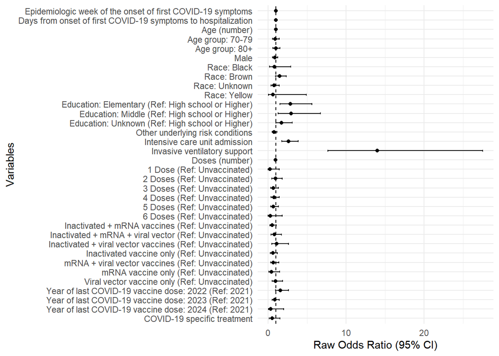

```r
coef_df <- rbind(
  epi_week_OR_raw, delta_days_OR_raw, age_OR_raw, age_groups_OR_raw,
  gender_OR_raw, race_OR_raw, education_level_OR_raw, # nominal_education_OR_raw,
  at_least_one_risk_OR_raw, nominal_icu_admission_OR_raw,
  nominal_invasive_support_ven_OR_raw, doses_OR_raw, ndoses_OR_raw,
  nominal_vaccinal_schema_OR_raw, last_year_OR_raw,
  nominal_covid_treatment_OR_raw
)
coef_df$Variable <- factor(coef_df$Variable, levels=rev(coef_df$Variable))

p = ggplot(coef_df, aes(x = Variable, y = OR)) +  # remove Intercept
  geom_point() +
  geom_errorbar(aes(ymin = LowerCI, ymax = UpperCI), width = 0.2) +
  geom_hline(yintercept = 1, linetype = "dashed") +
  coord_flip() +
  labs(#title = "Forest Plot of Logistic Regression",
       x = "Variables",
       y = "Raw Odds Ratio (95% CI)") +
  theme_minimal()

ggsave("raw_forest_plot.pdf", p, width = 8, height = 11)
p
```

## Time betwwen vaccination and outcome

```r
min(filtered$days_since_last_vaccine , na.rm = TRUE)
```

```
## [1] 63
```

```r
filtered$days_since_last_vaccine
```

[output not shown]

[output cut: 17 more lines]

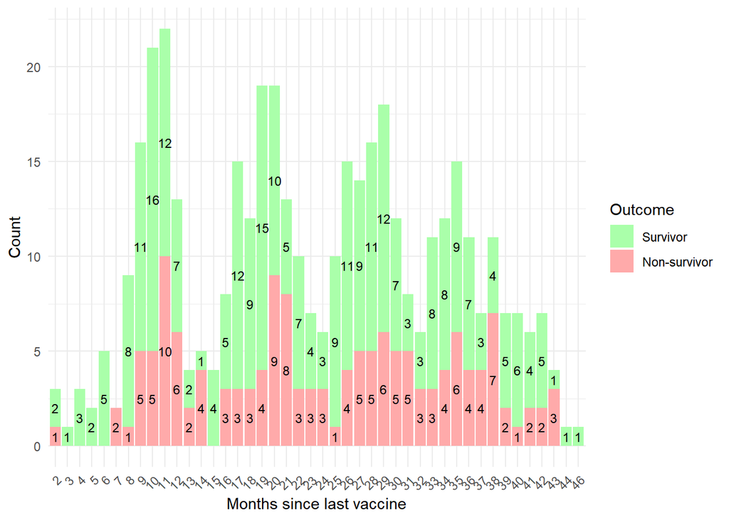

```r
breaks <- seq(
  0,
  max(filtered$days_since_last_vaccine, na.rm = TRUE) + 30,
  by = 30
)

labels <- paste0(
  head(breaks, -1) / 30
)

filtered %>%
  filter(
    !is.na(days_since_last_vaccine),
    !is.na(outcome)
  ) %>%
  ggplot(
    aes(
      x = cut(
        days_since_last_vaccine,
        breaks = breaks,
        labels = labels,
        include.lowest = TRUE
      ),
      fill = factor(outcome)
    )
  ) +
  #geom_bar(position = "fill", na.rm = TRUE) +
  geom_bar(na.rm = TRUE) +
  geom_text(
    stat = "count",
    aes(
      y = after_stat(count),
      label = after_stat(count),
      group = factor(outcome)
    ),
    #position = position_fill(vjust = 0.5),
    position = position_stack(vjust= 0.5),
    color = "black",
    size = 3,
    na.rm = TRUE
  ) +
  scale_fill_manual(
    values = c("0" = "#faa", "1" = "#afa"),
    labels = c("0" = "Non-survivor", "1" = "Survivor")
  ) +
  labs(
    x = "Months since last vaccine",
    y = "Count",
    fill = "Outcome"
  ) +
  theme_minimal() +
  theme(
    axis.text.x = element_text(angle = 45, hjust = 1)
  )
```

## Model

### Main Version - Variables from paper

Category: variable (Ref: value): groups…

#### Logistic Regression

```r
model <- glm(outcome ~ NU_IDADE_N + CS_SEXO +
               education_level +
               nominal_icu_admission +
               nominal_invasive_support_ven + categorical_doses,
               family = binomial,
               data = filtered)

summary_model <- summary(model)
print(summary_model)
```

```
##
## Call:
## glm(formula = outcome ~ NU_IDADE_N + CS_SEXO + education_level +
##     nominal_icu_admission + nominal_invasive_support_ven + categorical_doses,
##     family = binomial, data = filtered)
##
## Coefficients:
##                                  Estimate Std. Error z value Pr(>|z|)
## (Intercept)                     -2.040698   0.932136  -2.189  0.02858 *
## NU_IDADE_N                       0.009214   0.011312   0.815  0.41532
## CS_SEXOM                         0.069242   0.219842   0.315  0.75279
## education_levelElementary        1.078364   0.389687   2.767  0.00565 **
## education_levelMiddle            1.060408   0.482131   2.199  0.02785 *
## education_levelUnknown           0.563076   0.340037   1.656  0.09774 .
## nominal_icu_admissionYes         0.365988   0.254819   1.436  0.15093
## nominal_invasive_support_venYes  2.529359   0.359145   7.043 1.89e-12 ***
## categorical_doses1-2            -0.407902   0.373804  -1.091  0.27518
## categorical_doses3              -0.402041   0.383953  -1.047  0.29505
## categorical_doses4              -0.607060   0.381589  -1.591  0.11164
## categorical_doses5+             -0.586755   0.378867  -1.549  0.12145
## ---
## Signif. codes:  0 '***' 0.001 '**' 0.01 '*' 0.05 '.' 0.1 ' ' 1
##
## (Dispersion parameter for binomial family taken to be 1)
##
##     Null deviance: 619.85  on 473  degrees of freedom
## Residual deviance: 512.16  on 462  degrees of freedom
## AIC: 536.16
##
## Number of Fisher Scoring iterations: 4
```

```r
odds_ratios <- exp(coef(model))
conf_int <- exp(confint(model))
data.frame(
  variable = names(coef(model)),
  OR = round(odds_ratios, 2),
  IC_95_inf = round(conf_int[,1], 2),
  IC_95_sup = round(conf_int[,2], 2),
  pvalue = round(summary_model$coefficients[,4], 3)
)
```

|  | variable | OR | IC_95_inf | IC_95_sup | pvalue |
| --- | --- | --- | --- | --- | --- |
| (Intercept) | (Intercept) | 0.13 | 0.02 | 0.80 | 0.029 |
| NU_IDADE_N | NU_IDADE_N | 1.01 | 0.99 | 1.03 | 0.415 |
| CS_SEXOM | CS_SEXOM | 1.07 | 0.70 | 1.65 | 0.753 |
| education_levelElementary | education_levelElementary | 2.94 | 1.39 | 6.44 | 0.006 |
| education_levelMiddle | education_levelMiddle | 2.89 | 1.12 | 7.50 | 0.028 |
| education_levelUnknown | education_levelUnknown | 1.76 | 0.92 | 3.51 | 0.098 |
| nominal_icu_admissionYes | nominal_icu_admissionYes | 1.44 | 0.87 | 2.37 | 0.151 |
| nominal_invasive_support_venYes | nominal_invasive_support_venYes | 12.55 | 6.39 | 26.33 | 0.000 |
| categorical_doses1-2 | categorical_doses1-2 | 0.67 | 0.32 | 1.39 | 0.275 |
| categorical_doses3 | categorical_doses3 | 0.67 | 0.31 | 1.42 | 0.295 |

[output cut: 2 more lines]

#### Variance inflation factor

```r
vif_results <- car::vif(model)
print(vif_results)
```

```
##                                  GVIF Df GVIF^(1/(2*Df))
## NU_IDADE_N                   1.068068  1        1.033474
## CS_SEXO                      1.023759  1        1.011810
## education_level              1.149977  3        1.023564
## nominal_icu_admission        1.254092  1        1.119863
## nominal_invasive_support_ven 1.201453  1        1.096108
## categorical_doses            1.110703  4        1.013211
```

No multicollinearity detected.

#### Forest Plot

```r
label_map <- c(
  "NU_IDADE_N" = "Age",
  "CS_SEXOM" = "Male",
  "education_levelElementary" = "Elementary Education",
  "education_levelMiddle" = "Middle Education",
  "education_levelUnknown" = "Unknown Education",
  "nominal_icu_admissionYes" = "ICU Admission",
  "nominal_invasive_support_venYes" = "Invasive Ventilation",
  "categorical_doses1-2" = "1-2 Doses",
  "categorical_doses3" = "3 Doses",
  "categorical_doses4" = "4 Doses",
  "categorical_doses5+" = "5+ Doses"
)


coef_df <- as.data.frame(confint(model))  # 95% CI
```

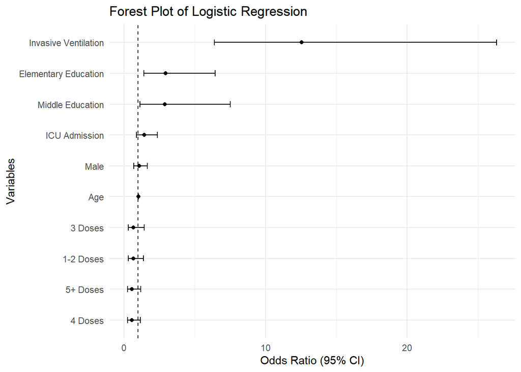

```r
coef_df$Estimate <- coef(model)
coef_df$OR <- exp(coef_df$Estimate)
coef_df$LowerCI <- exp(coef_df[, 1])
coef_df$UpperCI <- exp(coef_df[, 2])
coef_df$Variable <- label_map[rownames(coef_df)]
coef_df= coef_df[row.names(coef_df) != "education_levelUnknown",]

p = ggplot(coef_df[-1, ], aes(x = reorder(Variable, OR), y = OR)) +  # remove Intercept
  geom_point() +
  geom_errorbar(aes(ymin = LowerCI, ymax = UpperCI), width = 0.2) +
  geom_hline(yintercept = 1, linetype = "dashed") +
  coord_flip() +
  labs(title = "Forest Plot of Logistic Regression",
       x = "Variables",
       y = "Odds Ratio (95% CI)") +
  theme_minimal()

ggsave("forest_plot.pdf", p, width = 8, height = nrow(coef_df) * 0.4)
p
```

#### Hosmer-Lemeshow Test

```r
hl_test <- hoslem.test(model$y, fitted(model), g = 10)
print(hl_test)
```

```
##
##  Hosmer and Lemeshow goodness of fit (GOF) test
##
## data:  model$y, fitted(model)
## X-squared = 5.0032, df = 8, p-value = 0.7572
```

p-value > 0.05 -> no evidence of poor fit

#### ROC and AUC

```r
roc_obj <- roc(response = filtered$outcome,
               predictor = predict(model, type = "response"))
auc(roc_obj)
```

```
## Area under the curve: 0.7398
```

```r
ci.auc(roc_obj)
```

```
## 95% CI: 0.6915-0.788 (DeLong)
```

AUC between 0.7 and 0.8: acceptable ability to discriminate between classes Entire confidence interval above 0.5: model performs better than random

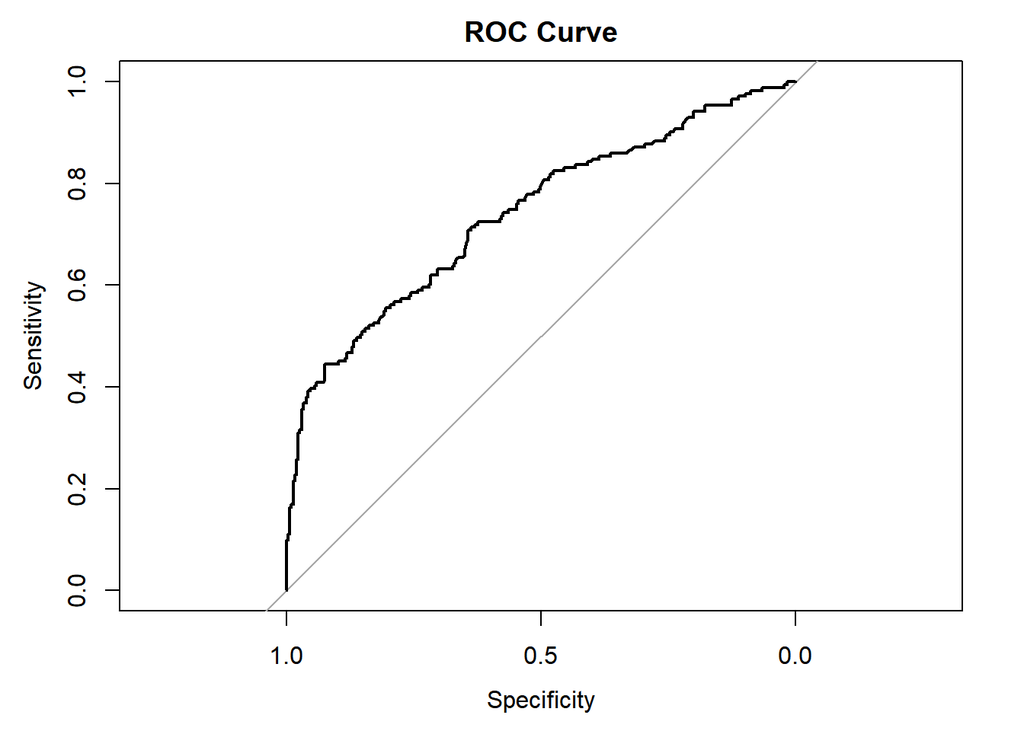

```r
plot(roc_obj, main = "ROC Curve")
```

## Alternative versions

### Alternative A - Main version, but it considers the interval since last vaccine

Category: variable (Ref: value): groups…

#### Logistic Regression

```r
model <- glm(outcome ~ NU_IDADE_N + CS_SEXO +
               education_level +
               nominal_icu_admission +
               nominal_invasive_support_ven +
               categorical_doses +
               last_vaccine_interval_broader,
               family = binomial,
               data = filtered)

summary_model <- summary(model)
print(summary_model)
```

```
##
## Call:
## glm(formula = outcome ~ NU_IDADE_N + CS_SEXO + education_level +
##     nominal_icu_admission + nominal_invasive_support_ven + categorical_doses +
##     last_vaccine_interval_broader, family = binomial, data = filtered)
##
## Coefficients:
##                                            Estimate Std. Error z value Pr(>|z|)
## (Intercept)                               -2.680326   0.977639  -2.742  0.00611
## NU_IDADE_N                                 0.009431   0.012039   0.783  0.43340
## CS_SEXOM                                   0.028277   0.237368   0.119  0.90517
## education_levelElementary                  1.346295   0.430485   3.127  0.00176
## education_levelMiddle                      1.274106   0.553342   2.303  0.02130
## education_levelUnknown                     0.844346   0.375416   2.249  0.02451
## nominal_icu_admissionYes                   0.343612   0.268977   1.277  0.20143
## nominal_invasive_support_venYes            2.459607   0.371825   6.615 3.72e-11
## categorical_doses3                         0.039423   0.338643   0.116  0.90733
## categorical_doses4                        -0.145793   0.334708  -0.436  0.66314
## categorical_doses5+                       -0.018990   0.390797  -0.049  0.96124
## last_vaccine_interval_broaderup to 1 year -0.242274   0.378783  -0.640  0.52243
##
## (Intercept)                               **
## NU_IDADE_N
## CS_SEXOM
## education_levelElementary                 **
## education_levelMiddle                     *
## education_levelUnknown                    *
## nominal_icu_admissionYes
## nominal_invasive_support_venYes           ***
## categorical_doses3
## categorical_doses4
## categorical_doses5+
## last_vaccine_interval_broaderup to 1 year
## ---
## Signif. codes:  0 '***' 0.001 '**' 0.01 '*' 0.05 '.' 0.1 ' ' 1
##
## (Dispersion parameter for binomial family taken to be 1)
##
##     Null deviance: 542.13  on 417  degrees of freedom
## Residual deviance: 443.88  on 406  degrees of freedom
##   (56 observations deleted due to missingness)
## AIC: 467.88
##
## Number of Fisher Scoring iterations: 4
```

```r
xtabs(~ categorical_doses + last_vaccine_interval_broader, data = filtered)
```

```
##                  last_vaccine_interval_broader
## categorical_doses over 1 year up to 1 year
##      unvaccinated           0            0
##      1-2                   99            1
##      3                     94            1
##      4                     94           18
##      5+                    43           68
```

```r
odds_ratios <- exp(coef(model))
conf_int <- exp(confint(model))
data.frame(
  variable = names(coef(model)),
  OR = round(odds_ratios, 2),
  IC_95_inf = round(conf_int[,1], 2),
  IC_95_sup = round(conf_int[,2], 2),
  pvalue = round(summary_model$coefficients[,4], 3)
)
```

|  | variable | OR | IC_95_inf | IC_95_sup | pvalue |
| --- | --- | --- | --- | --- | --- |
| (Intercept) | (Intercept) | 0.07 | 0.01 | 0.46 | 0.006 |
| NU_IDADE_N | NU_IDADE_N | 1.01 | 0.99 | 1.03 | 0.433 |
| CS_SEXOM | CS_SEXOM | 1.03 | 0.65 | 1.64 | 0.905 |
| education_levelElementary | education_levelElementary | 3.84 | 1.69 | 9.20 | 0.002 |
| education_levelMiddle | education_levelMiddle | 3.58 | 1.21 | 10.69 | 0.021 |
| education_levelUnknown | education_levelUnknown | 2.33 | 1.15 | 5.03 | 0.025 |
| nominal_icu_admissionYes | nominal_icu_admissionYes | 1.41 | 0.83 | 2.38 | 0.201 |
| nominal_invasive_support_venYes | nominal_invasive_support_venYes | 11.70 | 5.81 | 25.16 | 0.000 |
| categorical_doses3 | categorical_doses3 | 1.04 | 0.53 | 2.02 | 0.907 |
| categorical_doses4 | categorical_doses4 | 0.86 | 0.45 | 1.67 | 0.663 |

[output cut: 2 more lines]

#### Variance inflation factor

```r
vif_results <- car::vif(model)
print(vif_results)
```

```
##                                   GVIF Df GVIF^(1/(2*Df))
## NU_IDADE_N                    1.079603  1        1.039040
## CS_SEXO                       1.028971  1        1.014382
## education_level               1.158813  3        1.024870
## nominal_icu_admission         1.249966  1        1.118019
## nominal_invasive_support_ven  1.225559  1        1.107050
## categorical_doses             1.649277  3        1.086965
## last_vaccine_interval_broader 1.577699  1        1.256065
```

No multicollinearity detected.

#### Forest Plot

```r
label_map <- c(
  "NU_IDADE_N" = "Age",
  "CS_SEXOM" = "Male",
  "education_levelElementary" = "Elementary Education",
  "education_levelMiddle" = "Middle Education",
  "education_levelUnknown" = "Unknown Education",
  "nominal_icu_admissionYes" = "ICU Admission",
  "nominal_invasive_support_venYes" = "Invasive Ventilation",
  "categorical_doses1-2" = "1-2 Doses",
  "categorical_doses3" = "3 Doses",
  "categorical_doses4" = "4 Doses",
  "categorical_doses5+" = "5+ Doses",
  "last_vaccine_interval_broaderup to 1 year" = "Less than 1 year since last"
)


coef_df <- as.data.frame(confint(model))  # 95% CI
```

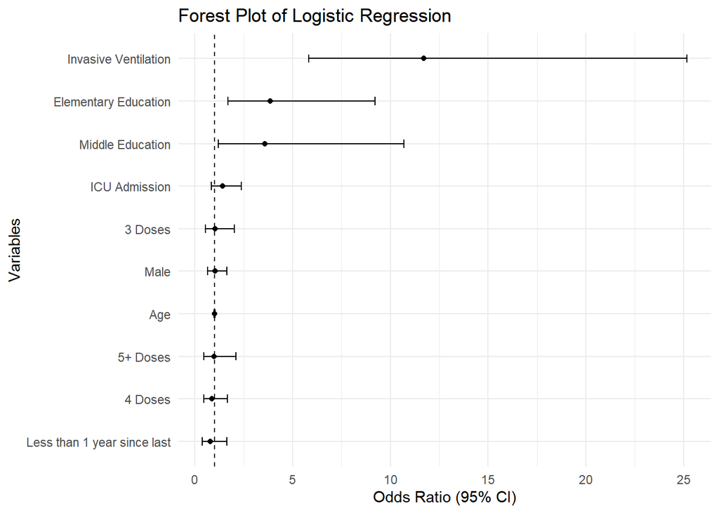

```r
coef_df$Estimate <- coef(model)
coef_df$OR <- exp(coef_df$Estimate)
coef_df$LowerCI <- exp(coef_df[, 1])
coef_df$UpperCI <- exp(coef_df[, 2])
coef_df$Variable <- label_map[rownames(coef_df)]
coef_df= coef_df[row.names(coef_df) != "education_levelUnknown",]

p = ggplot(coef_df[-1, ], aes(x = reorder(Variable, OR), y = OR)) +  # remove Intercept
  geom_point() +
  geom_errorbar(aes(ymin = LowerCI, ymax = UpperCI), width = 0.2) +
  geom_hline(yintercept = 1, linetype = "dashed") +
  coord_flip() +
  labs(title = "Forest Plot of Logistic Regression",
       x = "Variables",
       y = "Odds Ratio (95% CI)") +
  theme_minimal()

#ggsave("forest_plot.pdf", p, width = 8, height = nrow(coef_df) * 0.4)
p
```

#### Hosmer-Lemeshow Test

```r
hl_test <- hoslem.test(model$y, fitted(model), g = 10)
print(hl_test)
```

```
##
##  Hosmer and Lemeshow goodness of fit (GOF) test
##
## data:  model$y, fitted(model)
## X-squared = 8.7937, df = 8, p-value = 0.36
```

p-value > 0.05 -> no evidence of poor fit

#### ROC and AUC

```r
length(predict(model))
```

```
## [1] 418
```

```r
mf <- model.frame(model)

roc_obj <- roc(
  response  = mf$outcome,
  predictor = predict(model, type = "response")
)
auc(roc_obj)
```

```
## Area under the curve: 0.7567
```

```r
ci.auc(roc_obj)
```

```
## 95% CI: 0.7063-0.8071 (DeLong)
```

AUC between 0.7 and 0.8: acceptable ability to discriminate between classes Entire confidence interval above 0.5: model performs better than random

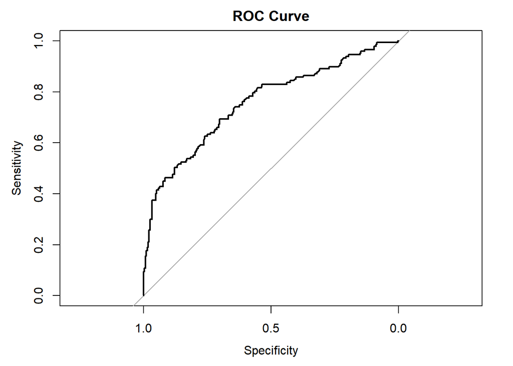

```r
plot(roc_obj, main = "ROC Curve")
```

### Alternative B - Main version, but splits high education level into Highschool and Bachelors

Category: variable (Ref: value): groups…

- Age: covariate NU_IDADE_N
- Gender: CS_SEXO (Ref: F): M
- Educational Attainment: nominal_education (Ref: Bachelor): Elementary, Middle, Highschool, Unknown
- ICU: nominal_icu_admission (Ref: No): Yes
- Invasive Support Ven: nominal_invasive_support_ven (Ref: No): Yes
- Doses: categorical_doses (Ref: unvaccinated): 1-2, 3, 4, 5+

#### Logistic Regression

```r
model <- glm(outcome ~ NU_IDADE_N + CS_SEXO +
               nominal_education +
               nominal_icu_admission +
               nominal_invasive_support_ven + categorical_doses,
               family = binomial,
               data = filtered)

summary_model <- summary(model)
print(summary_model)
```

```
##
## Call:
## glm(formula = outcome ~ NU_IDADE_N + CS_SEXO + nominal_education +
##     nominal_icu_admission + nominal_invasive_support_ven + categorical_doses,
##     family = binomial, data = filtered)
##
## Coefficients:
##                                  Estimate Std. Error z value Pr(>|z|)
## (Intercept)                     -2.590499   1.043181  -2.483   0.0130 *
## NU_IDADE_N                       0.008608   0.011283   0.763   0.4455
## CS_SEXOM                         0.058446   0.220281   0.265   0.7908
## nominal_educationElementary      1.678701   0.653227   2.570   0.0102 *
## nominal_educationHighschool      0.841233   0.697888   1.205   0.2280
## nominal_educationMiddle          1.656905   0.709355   2.336   0.0195 *
## nominal_educationUnknown         1.161896   0.622682   1.866   0.0620 .
## nominal_icu_admissionYes         0.370002   0.255073   1.451   0.1469
## nominal_invasive_support_venYes  2.564512   0.363684   7.051 1.77e-12 ***
## categorical_doses1-2            -0.401908   0.373959  -1.075   0.2825
## categorical_doses3              -0.415682   0.383667  -1.083   0.2786
## categorical_doses4              -0.613810   0.381905  -1.607   0.1080
## categorical_doses5+             -0.592463   0.378707  -1.564   0.1177
## ---
## Signif. codes:  0 '***' 0.001 '**' 0.01 '*' 0.05 '.' 0.1 ' ' 1
##
## (Dispersion parameter for binomial family taken to be 1)
##
##     Null deviance: 619.85  on 473  degrees of freedom
## Residual deviance: 510.62  on 461  degrees of freedom
## AIC: 536.62
##
## Number of Fisher Scoring iterations: 4
```

```r
odds_ratios <- exp(coef(model))
conf_int <- exp(confint(model))
data.frame(
  variable = names(coef(model)),
  OR = round(odds_ratios, 2),
  IC_95_inf = round(conf_int[,1], 2),
  IC_95_sup = round(conf_int[,2], 2),
  pvalue = round(summary_model$coefficients[,4], 3)
)
```

|  | variable | OR | IC_95_inf | IC_95_sup | pvalue |
| --- | --- | --- | --- | --- | --- |
| (Intercept) | (Intercept) | 0.07 | 0.01 | 0.57 | 0.013 |
| NU_IDADE_N | NU_IDADE_N | 1.01 | 0.99 | 1.03 | 0.445 |
| CS_SEXOM | CS_SEXOM | 1.06 | 0.69 | 1.64 | 0.791 |
| nominal_educationElementary | nominal_educationElementary | 5.36 | 1.62 | 21.35 | 0.010 |
| nominal_educationHighschool | nominal_educationHighschool | 2.32 | 0.63 | 9.90 | 0.228 |
| nominal_educationMiddle | nominal_educationMiddle | 5.24 | 1.39 | 22.91 | 0.020 |
| nominal_educationUnknown | nominal_educationUnknown | 3.20 | 1.03 | 12.06 | 0.062 |
| nominal_icu_admissionYes | nominal_icu_admissionYes | 1.45 | 0.87 | 2.38 | 0.147 |
| nominal_invasive_support_venYes | nominal_invasive_support_venYes | 12.99 | 6.57 | 27.57 | 0.000 |
| categorical_doses1-2 | categorical_doses1-2 | 0.67 | 0.32 | 1.40 | 0.282 |

[output cut: 3 more lines]

#### Variance inflation factor

```r
vif_results <- car::vif(model)
print(vif_results)
```

```
##                                  GVIF Df GVIF^(1/(2*Df))
## NU_IDADE_N                   1.070363  1        1.034584
## CS_SEXO                      1.025048  1        1.012447
## nominal_education            1.187828  4        1.021749
## nominal_icu_admission        1.253157  1        1.119445
## nominal_invasive_support_ven 1.217552  1        1.103427
## categorical_doses            1.114846  4        1.013682
```

No multicollinearity detected.

#### Forest Plot

```r
label_map <- c(
  "NU_IDADE_N" = "Age",
  "CS_SEXOM" = "Male",
  "nominal_educationElementary" = "Elementary Education",
  "nominal_educationHighschool" = "Highschool Education",
  "nominal_educationMiddle" = "Middle Education",
  "nominal_educationUnknown" = "Unknown Education",
  "nominal_icu_admissionYes" = "ICU Admission",
  "nominal_invasive_support_venYes" = "Invasive Ventilation",
  "categorical_doses1-2" = "1-2 Doses",
  "categorical_doses3" = "3 Doses",
  "categorical_doses4" = "4 Doses",
  "categorical_doses5+" = "5+ Doses"
)


coef_df <- as.data.frame(confint(model))  # 95% CI
```

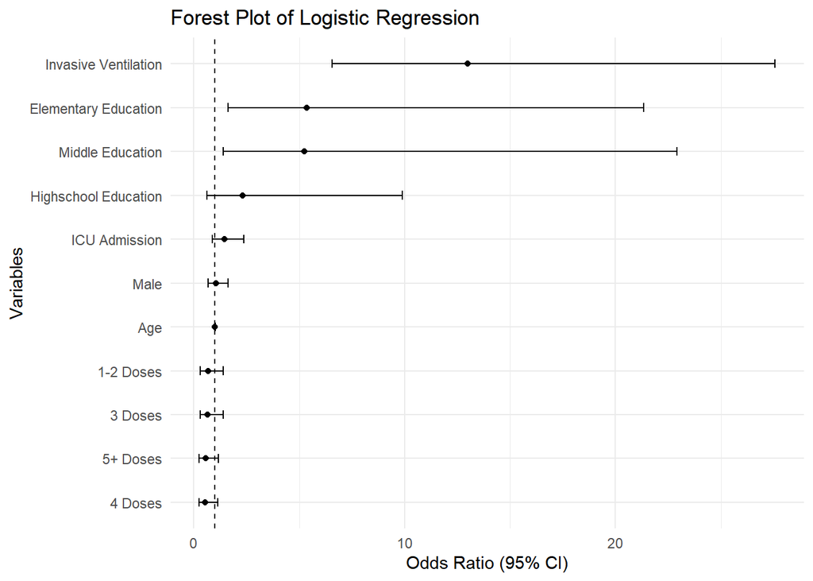

```r
coef_df$Estimate <- coef(model)
coef_df$OR <- exp(coef_df$Estimate)
coef_df$LowerCI <- exp(coef_df[, 1])
coef_df$UpperCI <- exp(coef_df[, 2])
coef_df$Variable <- label_map[rownames(coef_df)]
coef_df= coef_df[row.names(coef_df) != "nominal_educationUnknown",]

ggplot(coef_df[-1, ], aes(x = reorder(Variable, OR), y = OR)) +  # remove Intercept
  geom_point() +
  geom_errorbar(aes(ymin = LowerCI, ymax = UpperCI), width = 0.2) +
  geom_hline(yintercept = 1, linetype = "dashed") +
  coord_flip() +
  labs(title = "Forest Plot of Logistic Regression",
       x = "Variables",
       y = "Odds Ratio (95% CI)") +
  theme_minimal()
```

#### Hosmer-Lemeshow Test

```r
hl_test <- hoslem.test(model$y, fitted(model), g = 10)
print(hl_test)
```

```
##
##  Hosmer and Lemeshow goodness of fit (GOF) test
##
## data:  model$y, fitted(model)
## X-squared = 7.0241, df = 8, p-value = 0.534
```

p-value > 0.05 -> no evidence of poor fit

#### ROC and AUC

```r
roc_obj <- roc(response = filtered$outcome,
               predictor = predict(model, type = "response"))
auc(roc_obj)
```

```
## Area under the curve: 0.7431
```

```r
ci.auc(roc_obj)
```

```
## 95% CI: 0.6953-0.7909 (DeLong)
```

AUC between 0.7 and 0.8: acceptable ability to discriminate between classes Entire confidence interval above 0.5: model performs better than random

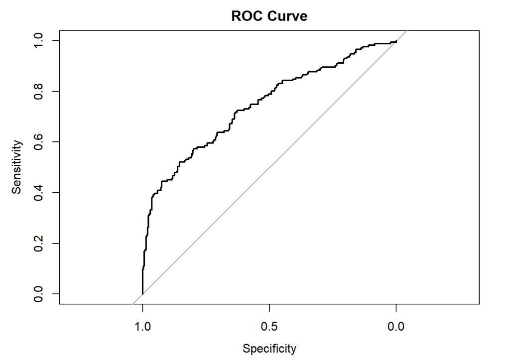

```r
plot(roc_obj, main = "ROC Curve")
```

### Alternative C - Alternative B, but using groups from bivariate analyses

Category: variable (Ref: ): groups…

#### Logistic Regression

```r
model <- glm(outcome ~ age_groups + CS_SEXO +
               nominal_education +
               nominal_icu_admission +
               nominal_invasive_support_ven + factor_doses,
               family = binomial,
               data = filtered)

summary_model <- summary(model)
print(summary_model)
```

```
##
## Call:
## glm(formula = outcome ~ age_groups + CS_SEXO + nominal_education +
##     nominal_icu_admission + nominal_invasive_support_ven + factor_doses,
##     family = binomial, data = filtered)
##
## Coefficients:
##                                 Estimate Std. Error z value Pr(>|z|)
## (Intercept)                     -1.94748    0.70280  -2.771  0.00559 **
## age_groups70-79                 -0.13463    0.27411  -0.491  0.62333
## age_groups80+                    0.07620    0.26975   0.282  0.77757
## CS_SEXOM                         0.07285    0.22132   0.329  0.74202
## nominal_educationElementary      1.71986    0.66664   2.580  0.00988 **
## nominal_educationHighschool      0.87045    0.71065   1.225  0.22063
## nominal_educationMiddle          1.64160    0.72248   2.272  0.02308 *
## nominal_educationUnknown         1.18474    0.63559   1.864  0.06232 .
## nominal_icu_admissionYes         0.37425    0.25539   1.465  0.14280
## nominal_invasive_support_venYes  2.57636    0.36545   7.050 1.79e-12 ***
## factor_doses1                   -1.82214    1.28285  -1.420  0.15550
## factor_doses2                   -0.34576    0.37878  -0.913  0.36133
## factor_doses3                   -0.43667    0.38561  -1.132  0.25746
## factor_doses4                   -0.63070    0.38391  -1.643  0.10041
## factor_doses5                   -0.54596    0.38261  -1.427  0.15360
## factor_doses6                   -1.74952    1.32179  -1.324  0.18564
## ---
## Signif. codes:  0 '***' 0.001 '**' 0.01 '*' 0.05 '.' 0.1 ' ' 1
##
## (Dispersion parameter for binomial family taken to be 1)
##
##     Null deviance: 619.85  on 473  degrees of freedom
## Residual deviance: 507.74  on 458  degrees of freedom
## AIC: 539.74
##
## Number of Fisher Scoring iterations: 4
```

```r
odds_ratios <- exp(coef(model))
conf_int <- exp(confint(model))
data.frame(
  variable = names(coef(model)),
  OR = round(odds_ratios, 2),
  IC_95_inf = round(conf_int[,1], 2),
  IC_95_sup = round(conf_int[,2], 2),
  pvalue = round(summary_model$coefficients[,4], 3)
)
```

|  | variable | OR | IC_95_inf | IC_95_sup | pvalue |
| --- | --- | --- | --- | --- | --- |
| (Intercept) | (Intercept) | 0.14 | 0.03 | 0.53 | 0.006 |
| age_groups70-79 | age_groups70-79 | 0.87 | 0.51 | 1.50 | 0.623 |
| age_groups80+ | age_groups80+ | 1.08 | 0.64 | 1.84 | 0.778 |
| CS_SEXOM | CS_SEXOM | 1.08 | 0.70 | 1.66 | 0.742 |
| nominal_educationElementary | nominal_educationElementary | 5.58 | 1.64 | 22.85 | 0.010 |
| nominal_educationHighschool | nominal_educationHighschool | 2.39 | 0.63 | 10.46 | 0.221 |
| nominal_educationMiddle | nominal_educationMiddle | 5.16 | 1.33 | 23.15 | 0.023 |
| nominal_educationUnknown | nominal_educationUnknown | 3.27 | 1.03 | 12.65 | 0.062 |
| nominal_icu_admissionYes | nominal_icu_admissionYes | 1.45 | 0.88 | 2.39 | 0.143 |
| nominal_invasive_support_venYes | nominal_invasive_support_venYes | 13.15 | 6.63 | 28.03 | 0.000 |

[output cut: 6 more lines]

#### Variance inflation factor

```r
vif_results <- car::vif(model)
print(vif_results)
```

```
##                                  GVIF Df GVIF^(1/(2*Df))
## age_groups                   1.084099  2        1.020392
## CS_SEXO                      1.029407  1        1.014597
## nominal_education            1.199530  4        1.023002
## nominal_icu_admission        1.254340  1        1.119973
## nominal_invasive_support_ven 1.218420  1        1.103821
## factor_doses                 1.158127  6        1.012309
```

No multicollinearity detected.

#### Forest Plot

```r
label_map <- c(
  "age_groups70-79" = "Age 70-79",
  "age_groups80+" = "Age 80+",
  "CS_SEXOM" = "Male",
  "nominal_educationElementary" = "Elementary Education",
  "nominal_educationHighschool" = "Highschool Education",
  "nominal_educationMiddle" = "Middle Education",
  "nominal_educationUnknown" = "Unknown Education",
  "nominal_icu_admissionYes" = "ICU Admission",
  "nominal_invasive_support_venYes" = "Invasive Ventilation",
  "factor_doses1" = "1 Dose",
  "factor_doses2" = "2 Doses",
  "factor_doses3" = "3 Doses",
  "factor_doses4" = "4 Doses",
  "factor_doses5" = "5 Doses"
)


coef_df <- as.data.frame(confint(model))  # 95% CI
```

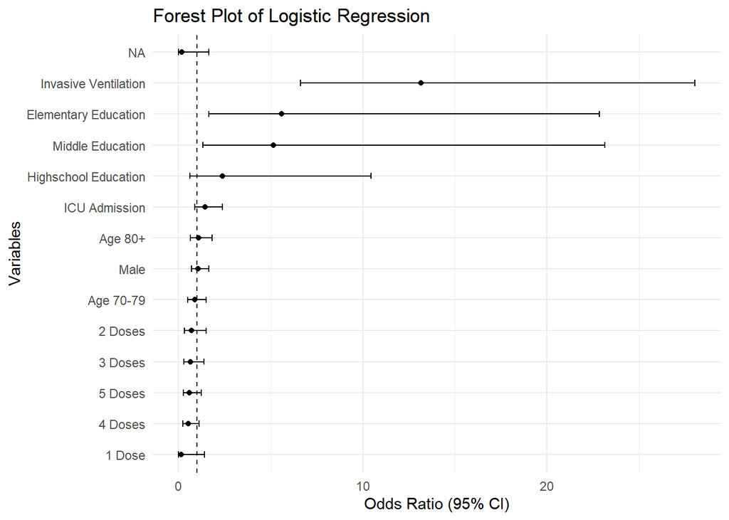

```r
coef_df$Estimate <- coef(model)
coef_df$OR <- exp(coef_df$Estimate)
coef_df$LowerCI <- exp(coef_df[, 1])
coef_df$UpperCI <- exp(coef_df[, 2])
coef_df$Variable <- label_map[rownames(coef_df)]
coef_df= coef_df[row.names(coef_df) != "nominal_educationUnknown",]

ggplot(coef_df[-1, ], aes(x = reorder(Variable, OR), y = OR)) +  # remove Intercept
  geom_point() +
  geom_errorbar(aes(ymin = LowerCI, ymax = UpperCI), width = 0.2) +
  geom_hline(yintercept = 1, linetype = "dashed") +
  coord_flip() +
  labs(title = "Forest Plot of Logistic Regression",
       x = "Variables",
       y = "Odds Ratio (95% CI)") +
  theme_minimal()
```

#### Hosmer-Lemeshow Test

```r
hl_test <- hoslem.test(model$y, fitted(model), g = 10)
print(hl_test)
```

```
##
##  Hosmer and Lemeshow goodness of fit (GOF) test
##
## data:  model$y, fitted(model)
## X-squared = 4.4189, df = 8, p-value = 0.8175
```

p-value > 0.05 -> no evidence of poor fit

#### ROC and AUC

```r
roc_obj <- roc(response = filtered$outcome,
               predictor = predict(model, type = "response"))
auc(roc_obj)
```

```
## Area under the curve: 0.7508
```

```r
ci.auc(roc_obj)
```

```
## 95% CI: 0.7041-0.7976 (DeLong)
```

AUC between 0.7 and 0.8: acceptable ability to discriminate between classes Entire confidence interval above 0.5: model performs better than random

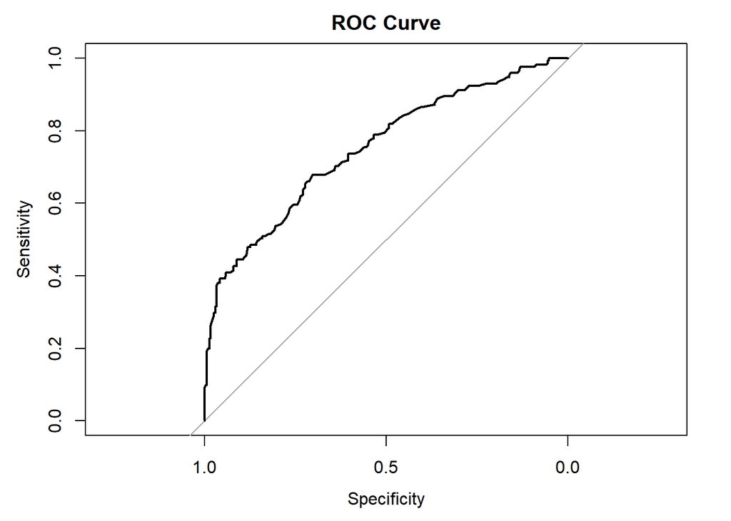

```r
plot(roc_obj, main = "ROC Curve")
```

### Alternative D - Alternative C, but age and doses are covariates

Category: variable (Ref: ): groups…

- Age: covariate NU_IDADE_N
- Gender: CS_SEXO (Ref: F): M
- Educational Attainment: nominal_education (Ref: Bachelor): Elementary, Middle, Highschool, Unknown
- ICU: nominal_icu_admission (Ref: No): Yes
- Invasive Support Ven: nominal_invasive_support_ven (Ref: No): Yes=
- Doses: covariate doses

#### Logistic Regression

```r
model <- glm(outcome ~ NU_IDADE_N + CS_SEXO +
               nominal_education +
               nominal_icu_admission +
               nominal_invasive_support_ven + doses,
               family = binomial,
               data = filtered)

summary_model <- summary(model)
print(summary_model)
```

```
##
## Call:
## glm(formula = outcome ~ NU_IDADE_N + CS_SEXO + nominal_education +
##     nominal_icu_admission + nominal_invasive_support_ven + doses,
##     family = binomial, data = filtered)
##
## Coefficients:
##                                  Estimate Std. Error z value Pr(>|z|)
## (Intercept)                     -2.687316   1.018435  -2.639  0.00832 **
## NU_IDADE_N                       0.008668   0.011257   0.770  0.44127
## CS_SEXOM                         0.055478   0.219785   0.252  0.80072
## nominal_educationElementary      1.656088   0.647406   2.558  0.01053 *
## nominal_educationHighschool      0.846588   0.693633   1.221  0.22227
## nominal_educationMiddle          1.662971   0.703020   2.365  0.01801 *
## nominal_educationUnknown         1.157890   0.617952   1.874  0.06096 .
## nominal_icu_admissionYes         0.358612   0.254405   1.410  0.15865
## nominal_invasive_support_venYes  2.559883   0.363248   7.047 1.83e-12 ***
## doses                           -0.110484   0.068811  -1.606  0.10836
## ---
## Signif. codes:  0 '***' 0.001 '**' 0.01 '*' 0.05 '.' 0.1 ' ' 1
##
## (Dispersion parameter for binomial family taken to be 1)
##
##     Null deviance: 619.85  on 473  degrees of freedom
## Residual deviance: 511.15  on 464  degrees of freedom
## AIC: 531.15
##
## Number of Fisher Scoring iterations: 4
```

```r
odds_ratios <- exp(coef(model))
conf_int <- exp(confint(model))
data.frame(
  variable = names(coef(model)),
  OR = round(odds_ratios, 2),
  IC_95_inf = round(conf_int[,1], 2),
  IC_95_sup = round(conf_int[,2], 2),
  pvalue = round(summary_model$coefficients[,4], 3)
)
```

|  | variable | OR | IC_95_inf | IC_95_sup | pvalue |
| --- | --- | --- | --- | --- | --- |
| (Intercept) | (Intercept) | 0.07 | 0.01 | 0.49 | 0.008 |
| NU_IDADE_N | NU_IDADE_N | 1.01 | 0.99 | 1.03 | 0.441 |
| CS_SEXOM | CS_SEXOM | 1.06 | 0.69 | 1.63 | 0.801 |
| nominal_educationElementary | nominal_educationElementary | 5.24 | 1.59 | 20.61 | 0.011 |
| nominal_educationHighschool | nominal_educationHighschool | 2.33 | 0.63 | 9.87 | 0.222 |
| nominal_educationMiddle | nominal_educationMiddle | 5.27 | 1.41 | 22.76 | 0.018 |
| nominal_educationUnknown | nominal_educationUnknown | 3.18 | 1.03 | 11.90 | 0.061 |
| nominal_icu_admissionYes | nominal_icu_admissionYes | 1.43 | 0.86 | 2.35 | 0.159 |
| nominal_invasive_support_venYes | nominal_invasive_support_venYes | 12.93 | 6.55 | 27.43 | 0.000 |
| doses | doses | 0.90 | 0.78 | 1.02 | 0.108 |

#### Variance inflation factor

```r
vif_results <- car::vif(model)
print(vif_results)
```

```
##                                  GVIF Df GVIF^(1/(2*Df))
## NU_IDADE_N                   1.068426  1        1.033647
## CS_SEXO                      1.021925  1        1.010903
## nominal_education            1.134606  4        1.015911
## nominal_icu_admission        1.247004  1        1.116693
## nominal_invasive_support_ven 1.213735  1        1.101696
## doses                        1.054865  1        1.027066
```

No multicollinearity detected.

#### Forest Plot

```r
label_map <- c(
  "NU_IDADE_N" = "Age",
  "CS_SEXOM" = "Male",
  "nominal_educationElementary" = "Elementary Education",
  "nominal_educationHighschool" = "Highschool Education",
  "nominal_educationMiddle" = "Middle Education",
  "nominal_educationUnknown" = "Unknown Education",
  "nominal_icu_admissionYes" = "ICU Admission",
  "nominal_invasive_support_venYes" = "Invasive Ventilation",
  "doses" = "Doses"
)


coef_df <- as.data.frame(confint(model))  # 95% CI
```

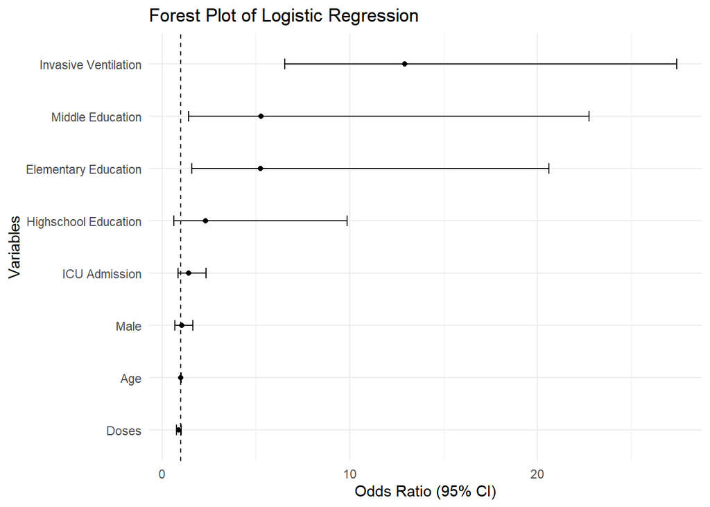

```r
coef_df$Estimate <- coef(model)
coef_df$OR <- exp(coef_df$Estimate)
coef_df$LowerCI <- exp(coef_df[, 1])
coef_df$UpperCI <- exp(coef_df[, 2])
coef_df$Variable <- label_map[rownames(coef_df)]
coef_df= coef_df[row.names(coef_df) != "nominal_educationUnknown",]

ggplot(coef_df[-1, ], aes(x = reorder(Variable, OR), y = OR)) +  # remove Intercept
  geom_point() +
  geom_errorbar(aes(ymin = LowerCI, ymax = UpperCI), width = 0.2) +
  geom_hline(yintercept = 1, linetype = "dashed") +
  coord_flip() +
  labs(title = "Forest Plot of Logistic Regression",
       x = "Variables",
       y = "Odds Ratio (95% CI)") +
  theme_minimal()
```

#### Hosmer-Lemeshow Test

```r
hl_test <- hoslem.test(model$y, fitted(model), g = 10)
print(hl_test)
```

```
##
##  Hosmer and Lemeshow goodness of fit (GOF) test
##
## data:  model$y, fitted(model)
## X-squared = 1.8567, df = 8, p-value = 0.9851
```

p-value > 0.05 -> no evidence of poor fit

#### ROC and AUC

```r
roc_obj <- roc(response = filtered$outcome,
               predictor = predict(model, type = "response"))
auc(roc_obj)
```

```
## Area under the curve: 0.7419
```

```r
ci.auc(roc_obj)
```

```
## 95% CI: 0.6938-0.79 (DeLong)
```

AUC between 0.7 and 0.8: acceptable ability to discriminate between classes Entire confidence interval above 0.5: model performs better than random

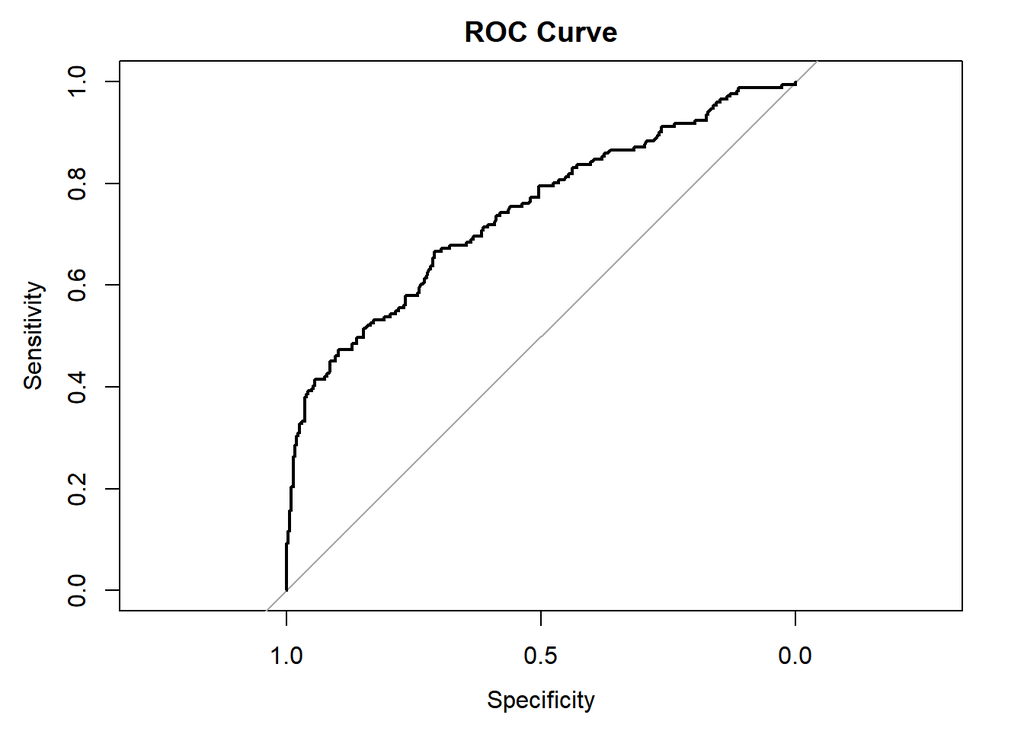

```r
plot(roc_obj, main = "ROC Curve")
```

### Alternative E - Alternative D, but it includes all categories from bivariate analyses

Category: variable (Ref: ): groups…

#### Logistic Regression

```r
filtered$nominal_vaccinal_schema <- factor(
  filtered$nominal_vaccinal_schema,
  levels = levels(filtered$nominal_vaccinal_schema)
)

model <- glm(outcome ~ delta_days + NU_IDADE_N + CS_SEXO +
               nominal_race +
               nominal_education +
               additional_risk_comorbidities +
               nominal_icu_admission +
               nominal_invasive_support_ven +
               doses +
               nominal_vaccinal_schema +
               last_year +
               nominal_covid_treatment,
               family = binomial,
               data = filtered)

summary_model <- summary(model)
print(summary_model)
```

```
##
## Call:
## glm(formula = outcome ~ delta_days + NU_IDADE_N + CS_SEXO + nominal_race +
##     nominal_education + additional_risk_comorbidities + nominal_icu_admission +
##     nominal_invasive_support_ven + doses + nominal_vaccinal_schema +
##     last_year + nominal_covid_treatment, family = binomial, data = filtered)
##
## Coefficients:
##                                                          Estimate Std. Error
## (Intercept)                                              -3.31409    2.65335
## delta_days                                               -0.04275    0.02848
## NU_IDADE_N                                                0.02482    0.01393
## CS_SEXOM                                                  0.13925    0.24963
## nominal_raceBlack                                         0.35458    1.06268
## nominal_raceBrown                                         0.49023    0.30487
## nominal_raceUnknown                                       0.18784    0.42084
## nominal_raceYellow                                        0.16269    1.23857
## nominal_educationElementary                               1.45709    0.69560
## nominal_educationHighschool                               0.48380    0.75509
## nominal_educationMiddle                                   1.59383    0.78461
## nominal_educationUnknown                                  0.99758    0.66322
## additional_risk_comorbidities                            -0.19310    0.11664
## nominal_icu_admissionYes                                  0.50785    0.29580
## nominal_invasive_support_venYes                           2.63834    0.40998
## doses                                                    -0.12700    0.23107
## nominal_vaccinal_schemaInactivated + mRNA                -0.84109    2.39270
## nominal_vaccinal_schemaInactivated + mRNA + viral vector -0.24897    2.42230
## nominal_vaccinal_schemaInactivated + Viral vector        -0.70372    2.39199
## nominal_vaccinal_schemaInactivated only                  -0.70834    2.39020
## nominal_vaccinal_schemamRNA + viral vector               -0.38586    2.39747
## nominal_vaccinal_schemamRNA only                         -1.31187    2.47551
## nominal_vaccinal_schemaViral vector only                 -0.03772    2.35250
## last_year2022                                             0.55855    0.48196
## last_year2023                                             0.31857    0.70646
## last_year2024                                            -0.95293    1.58518
## nominal_covid_treatmentYes                               -2.17183    1.23411
##                                                          z value Pr(>|z|)
## (Intercept)                                               -1.249   0.2117
## delta_days                                                -1.501   0.1334
## NU_IDADE_N                                                 1.782   0.0748 .
```

[output cut: 20 more lines]

```
## last_year2022                                              1.159   0.2465
## last_year2023                                              0.451   0.6520
## last_year2024                                             -0.601   0.5477
## nominal_covid_treatmentYes                                -1.760   0.0784 .
## ---
## Signif. codes:  0 '***' 0.001 '**' 0.01 '*' 0.05 '.' 0.1 ' ' 1
##
## (Dispersion parameter for binomial family taken to be 1)
##
##     Null deviance: 542.13  on 417  degrees of freedom
## Residual deviance: 420.12  on 391  degrees of freedom
##   (56 observations deleted due to missingness)
## AIC: 474.12
##
## Number of Fisher Scoring iterations: 5
```

```r
odds_ratios <- exp(coef(model))
conf_int <- exp(confint(model))
data.frame(
  variable = names(coef(model)),
  OR = round(odds_ratios, 2),
  IC_95_inf = round(conf_int[,1], 2),
  IC_95_sup = round(conf_int[,2], 2),
  pvalue = round(summary_model$coefficients[,4], 3)
)
```

|  | variable | OR | IC_95_inf | IC_95_sup | pvalue |
| --- | --- | --- | --- | --- | --- |
| (Intercept) | (Intercept) | 0.04 | 0.00 | 8.02 | 0.212 |
| delta_days | delta_days | 0.96 | 0.90 | 1.01 | 0.133 |
| NU_IDADE_N | NU_IDADE_N | 1.03 | 1.00 | 1.05 | 0.075 |
| CS_SEXOM | CS_SEXOM | 1.15 | 0.71 | 1.88 | 0.577 |
| nominal_raceBlack | nominal_raceBlack | 1.43 | 0.14 | 10.19 | 0.739 |
| nominal_raceBrown | nominal_raceBrown | 1.63 | 0.90 | 2.97 | 0.108 |
| nominal_raceUnknown | nominal_raceUnknown | 1.21 | 0.52 | 2.72 | 0.655 |
| nominal_raceYellow | nominal_raceYellow | 1.18 | 0.05 | 11.12 | 0.895 |
| nominal_educationElementary | nominal_educationElementary | 4.29 | 1.20 | 19.13 | 0.036 |
| nominal_educationHighschool | nominal_educationHighschool | 1.62 | 0.39 | 7.86 | 0.522 |

[output cut: 17 more lines]

#### Variance inflation factor

```r
vif_results <- car::vif(model)
print(vif_results)
```

```
##                                    GVIF Df GVIF^(1/(2*Df))
## delta_days                     1.072189  1        1.035466
## NU_IDADE_N                     1.399091  1        1.182832
## CS_SEXO                        1.070896  1        1.034841
## nominal_race                   1.540999  4        1.055541
## nominal_education              1.445236  4        1.047110
## additional_risk_comorbidities  1.150630  1        1.072674
## nominal_icu_admission          1.427255  1        1.194678
## nominal_invasive_support_ven   1.375957  1        1.173012
## doses                          5.056808  1        2.248735
## nominal_vaccinal_schema       11.160259  7        1.188048
## last_year                      9.817672  3        1.463305
## nominal_covid_treatment        1.125500  1        1.060896
```

Doses and vaccinal schema might have some colinearity.

#### Forest Plot

```r
label_map <- c(
  "NU_IDADE_N" = "Age",
  "CS_SEXOM" = "Male",
  "nominal_educationElementary" = "Elementary Education",
  "nominal_educationHighschool" = "Highschool Education",
  "nominal_educationMiddle" = "Middle Education",
  "nominal_educationUnknown" = "Unknown Education",
  "nominal_icu_admissionYes" = "ICU Admission",
  "nominal_invasive_support_venYes" = "Invasive Ventilation",
  "additional_risk_comorbidities" = "Comorbidities",
  "doses" = "Doses",
  "nominal_vaccinal_schemaInactivated + mRNA + viral vector" = "Inactivated + mRNA + viral vector",
  "nominal_vaccinal_schemaInactivated + Viral vector" = "Inactivated + Viral vector",
  "nominal_vaccinal_schemaInactivated only" = "Inactivated only",
  "nominal_vaccinal_schemaViral vector only" = "Viral vector only",
  "last_year" = "Last Vaccine Year",
  "nominal_covid_treatmentYes" = "COVID Treatment",
  "nominal_raceBlack" = "Black",
  "nominal_raceBrown" = "Brown",
  "nominal_raceUnknown" = "Unknown Race",
  "nominal_raceYellow" = "Yellow",
  "delta_days" = "Days since the beginning of the infection",
  "nominal_vaccinal_schemamRNA + viral vector" = "mRNA + viral vector",
  "nominal_vaccinal_schemamRNA only" = "mRNA only"
)

coef_df <- as.data.frame(confint(model))  # 95% CI
```

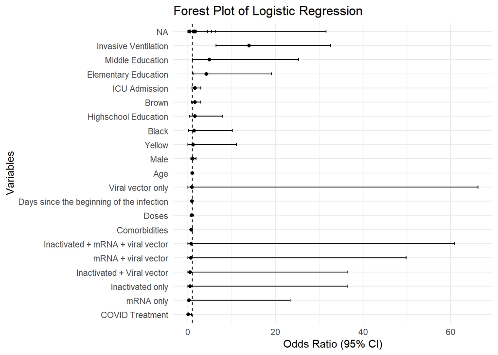

```r
coef_df$Estimate <- coef(model)
coef_df$OR <- exp(coef_df$Estimate)
coef_df$LowerCI <- exp(coef_df[, 1])
coef_df$UpperCI <- exp(coef_df[, 2])
#coef_df$Variable <- rownames(coef_df)

coef_df$Variable <- label_map[rownames(coef_df)]
coef_df= coef_df[row.names(coef_df) != "nominal_educationUnknown" & row.names(coef_df) != "nominal_raceUnknown" ,]

ggplot(coef_df[-1, ], aes(x = reorder(Variable, OR), y = OR)) +  # remove Intercept
  geom_point() +
  geom_errorbar(aes(ymin = LowerCI, ymax = UpperCI), width = 0.2) +
  geom_hline(yintercept = 1, linetype = "dashed") +
  coord_flip() +
  labs(title = "Forest Plot of Logistic Regression",
       x = "Variables",
       y = "Odds Ratio (95% CI)") +
  theme_minimal()
```

#### Hosmer-Lemeshow Test

```r
hl_test <- hoslem.test(model$y, fitted(model), g = 10)
print(hl_test)
```

```
##
##  Hosmer and Lemeshow goodness of fit (GOF) test
##
## data:  model$y, fitted(model)
## X-squared = 3.2172, df = 8, p-value = 0.92
```

p-value > 0.05 -> no evidence of poor fit

### Alternative F - Alternative D, but doses and are are categorical

Category: variable (Ref: ): groups…

- Age: age_groups (Ref: 60–69): 70-79, 80+
- ICU: nominal_icu_admission (Ref: No): Yes
- Invasive Support Ven: nominal_invasive_support_ven (Ref: No): Yes
- Gender: CS_SEXO (Ref: F): M
- Doses: categorical_doses (Ref: unvaccinated): 1-2, 3, 4, 5+
- Educational Attainment: educational_attainment (Ref: bachelor): low, unknown

#### Logistic Regression

```r
model <- glm(outcome ~ age_groups + nominal_icu_admission +
               nominal_invasive_support_ven + CS_SEXO +
               categorical_doses +
               educational_attainment,
               family = binomial,
               data = filtered)

summary_model <- summary(model)
print(summary_model)
```

```
##
## Call:
## glm(formula = outcome ~ age_groups + nominal_icu_admission +
##     nominal_invasive_support_ven + CS_SEXO + categorical_doses +
##     educational_attainment, family = binomial, data = filtered)
##
## Coefficients:
##                                 Estimate Std. Error z value Pr(>|z|)
## (Intercept)                     -1.88617    0.69655  -2.708  0.00677 **
## age_groups70-79                 -0.12722    0.27159  -0.468  0.63948
## age_groups80+                    0.13245    0.26533   0.499  0.61765
## nominal_icu_admissionYes         0.35219    0.25247   1.395  0.16303
## nominal_invasive_support_venYes  2.58869    0.36007   7.189  6.5e-13 ***
## CS_SEXOM                         0.04112    0.21918   0.188  0.85119
## categorical_doses1-2            -0.38303    0.37319  -1.026  0.30471
## categorical_doses3              -0.53548    0.37957  -1.411  0.15831
## categorical_doses4              -0.68220    0.37758  -1.807  0.07080 .
## categorical_doses5+             -0.67934    0.37487  -1.812  0.06996 .
## educational_attainmentlow        1.45115    0.63799   2.275  0.02293 *
## educational_attainmentunknown    1.16616    0.63106   1.848  0.06461 .
## ---
## Signif. codes:  0 '***' 0.001 '**' 0.01 '*' 0.05 '.' 0.1 ' ' 1
##
## (Dispersion parameter for binomial family taken to be 1)
##
##     Null deviance: 619.85  on 473  degrees of freedom
## Residual deviance: 514.90  on 462  degrees of freedom
## AIC: 538.9
##
## Number of Fisher Scoring iterations: 4
```

```r
odds_ratios <- exp(coef(model))
conf_int <- exp(confint(model))
data.frame(
  variable = names(coef(model)),
  OR = round(odds_ratios, 2),
  IC_95_inf = round(conf_int[,1], 2),
  IC_95_sup = round(conf_int[,2], 2),
  pvalue = round(summary_model$coefficients[,4], 3)
)
```

|  | variable | OR | IC_95_inf | IC_95_sup | pvalue |
| --- | --- | --- | --- | --- | --- |
| (Intercept) | (Intercept) | 0.15 | 0.04 | 0.56 | 0.007 |
| age_groups70-79 | age_groups70-79 | 0.88 | 0.52 | 1.50 | 0.639 |
| age_groups80+ | age_groups80+ | 1.14 | 0.68 | 1.93 | 0.618 |
| nominal_icu_admissionYes | nominal_icu_admissionYes | 1.42 | 0.86 | 2.32 | 0.163 |
| nominal_invasive_support_venYes | nominal_invasive_support_venYes | 13.31 | 6.78 | 28.06 | 0.000 |
| CS_SEXOM | CS_SEXOM | 1.04 | 0.68 | 1.60 | 0.851 |
| categorical_doses1-2 | categorical_doses1-2 | 0.68 | 0.33 | 1.42 | 0.305 |
| categorical_doses3 | categorical_doses3 | 0.59 | 0.28 | 1.23 | 0.158 |
| categorical_doses4 | categorical_doses4 | 0.51 | 0.24 | 1.06 | 0.071 |
| categorical_doses5+ | categorical_doses5+ | 0.51 | 0.24 | 1.06 | 0.070 |

[output cut: 2 more lines]

#### Variance inflation factor

```r
vif_results <- car::vif(model)
print(vif_results)
```

```
##                                  GVIF Df GVIF^(1/(2*Df))
## age_groups                   1.064477  2        1.015744
## nominal_icu_admission        1.235072  1        1.111338
## nominal_invasive_support_ven 1.200929  1        1.095869
## CS_SEXO                      1.025043  1        1.012444
## categorical_doses            1.059239  4        1.007220
## educational_attainment       1.084161  2        1.020407
```

No multicollinearity detected.

#### Forest Plot

```r
label_map <- c(
  "age_groups70-79" = "Age 70-79",
  "age_groups80+" = "Age 80+",
  "CS_SEXOM" = "Male",
  "educational_attainmentlow" = "Low Education",
  "educational_attainmentunknown" = "Unknown Education",
  "nominal_educationMiddle" = "Middle Education",
  "nominal_educationUnknown" = "Unknown Education",
  "nominal_icu_admissionYes" = "ICU Admission",
  "nominal_invasive_support_venYes" = "Invasive Ventilation",
  "categorical_doses1-2" = "1-2 Doses",
  "categorical_doses3" = "3 Doses",
  "categorical_doses4" = "4 Doses",
  "categorical_doses5+" = "5+ Doses"
)


coef_df <- as.data.frame(confint(model))  # 95% CI
```

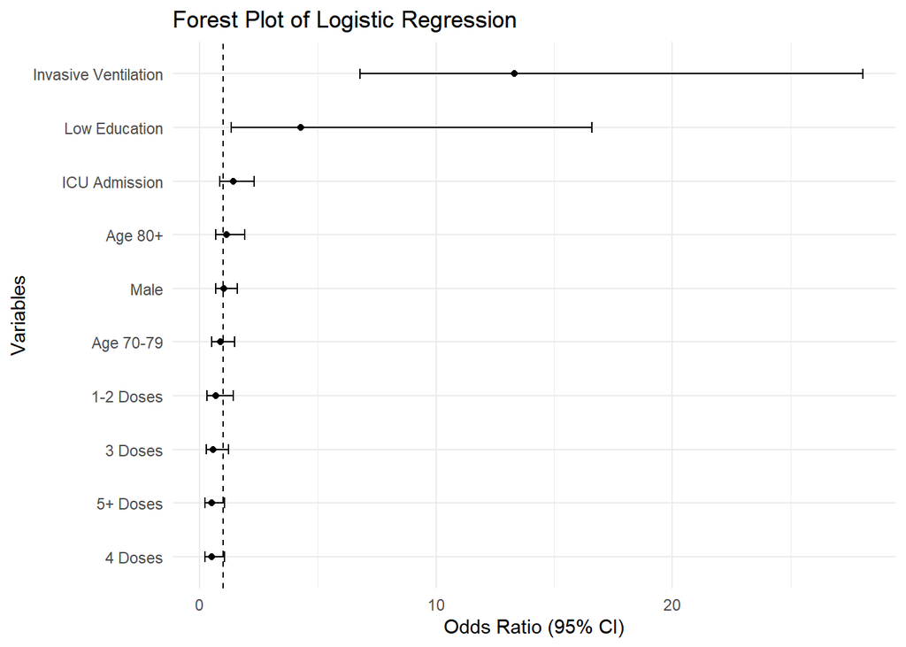

```r
coef_df$Estimate <- coef(model)
coef_df$OR <- exp(coef_df$Estimate)
coef_df$LowerCI <- exp(coef_df[, 1])
coef_df$UpperCI <- exp(coef_df[, 2])
coef_df$Variable <- label_map[rownames(coef_df)]
coef_df= coef_df[row.names(coef_df) != "educational_attainmentunknown",]

ggplot(coef_df[-1, ], aes(x = reorder(Variable, OR), y = OR)) +  # remove Intercept
  geom_point() +
  geom_errorbar(aes(ymin = LowerCI, ymax = UpperCI), width = 0.2) +
  geom_hline(yintercept = 1, linetype = "dashed") +
  coord_flip() +
  labs(title = "Forest Plot of Logistic Regression",
       x = "Variables",
       y = "Odds Ratio (95% CI)") +
  theme_minimal()
```

#### Hosmer-Lemeshow Test

```r
hl_test <- hoslem.test(model$y, fitted(model), g = 10)
print(hl_test)
```

```
##
##  Hosmer and Lemeshow goodness of fit (GOF) test
##
## data:  model$y, fitted(model)
## X-squared = 2.2298, df = 8, p-value = 0.9731
```

p-value > 0.05 -> no evidence of poor fit

#### ROC and AUC

```r
roc_obj <- roc(response = filtered$outcome,
               predictor = predict(model, type = "response"))
auc(roc_obj)
```

```
## Area under the curve: 0.7303
```

```r
ci.auc(roc_obj)
```

```
## 95% CI: 0.681-0.7795 (DeLong)
```

AUC between 0.7 and 0.8: acceptable ability to discriminate between classes Entire confidence interval above 0.5: model performs better than random

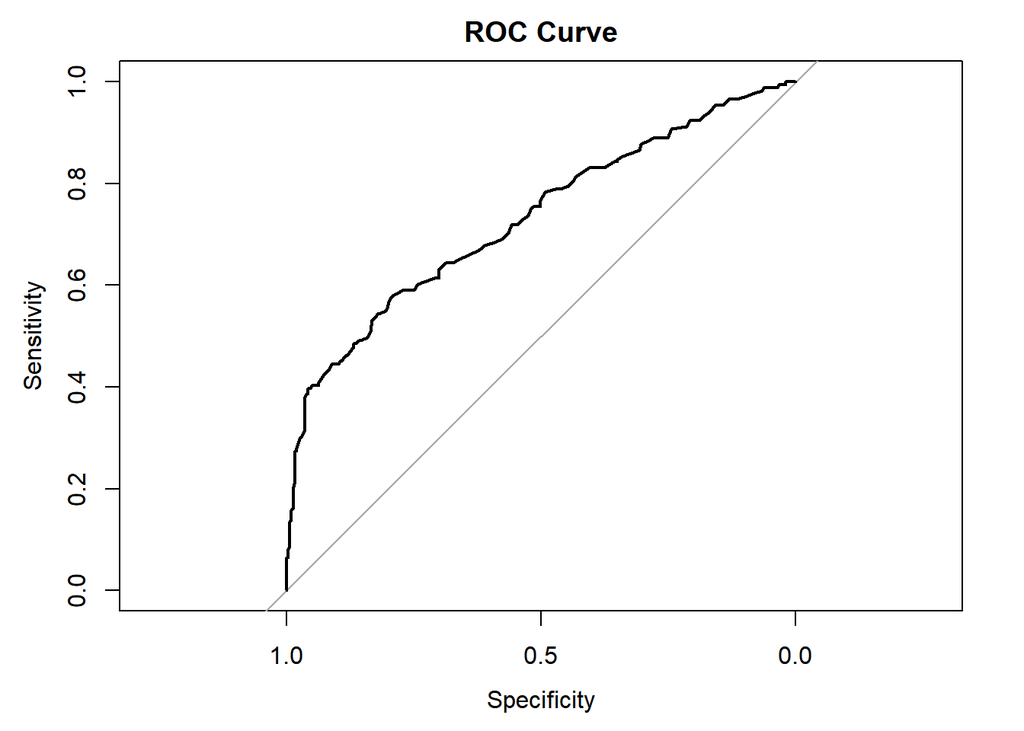

```r
plot(roc_obj, main = "ROC Curve")
```

## Vaccination schema

```r
filtered$vaccinal_schema_based_on_innactivated <- relevel(factor(filtered$vaccinal_schema_based_on_innactivated), ref="unvaccinated or single-dose")
model <- glm(outcome ~ vaccinal_schema_based_on_innactivated,
               family = binomial,
               data = filtered)

summary_model <- summary(model)
print(summary_model)
```

```
##
## Call:
## glm(formula = outcome ~ vaccinal_schema_based_on_innactivated,
##     family = binomial, data = filtered)
##
## Coefficients:
##                                                                             Estimate
## (Intercept)                                                                  -0.3677
## vaccinal_schema_based_on_innactivatedsequential excluding inactivated        -0.1368
## vaccinal_schema_based_on_innactivatedsequential with inactivated and others  -0.2672
## vaccinal_schema_based_on_innactivatedsequential with inactivated only        -0.3969
##                                                                             Std. Error
## (Intercept)                                                                     0.2504
## vaccinal_schema_based_on_innactivatedsequential excluding inactivated           0.2962
## vaccinal_schema_based_on_innactivatedsequential with inactivated and others     0.3026
## vaccinal_schema_based_on_innactivatedsequential with inactivated only           0.3420
##                                                                             z value
## (Intercept)                                                                  -1.469
## vaccinal_schema_based_on_innactivatedsequential excluding inactivated        -0.462
## vaccinal_schema_based_on_innactivatedsequential with inactivated and others  -0.883
## vaccinal_schema_based_on_innactivatedsequential with inactivated only        -1.161
##                                                                             Pr(>|z|)
## (Intercept)                                                                    0.142
## vaccinal_schema_based_on_innactivatedsequential excluding inactivated          0.644
## vaccinal_schema_based_on_innactivatedsequential with inactivated and others    0.377
## vaccinal_schema_based_on_innactivatedsequential with inactivated only          0.246
##
## (Dispersion parameter for binomial family taken to be 1)
##
##     Null deviance: 619.85  on 473  degrees of freedom
## Residual deviance: 618.18  on 470  degrees of freedom
## AIC: 626.18
##
## Number of Fisher Scoring iterations: 4
```

```r
filtered$nominal_vaccinal_schema <- relevel(factor(filtered$nominal_vaccinal_schema), ref="None")
model <- glm(outcome ~ nominal_vaccinal_schema,
               family = binomial,
               data = filtered)

summary_model <- summary(model)
print(summary_model)
```

```
##
## Call:
## glm(formula = outcome ~ nominal_vaccinal_schema, family = binomial,
##     data = filtered)
##
## Coefficients:
##                                                          Estimate Std. Error
## (Intercept)                                              -0.27763    0.26515
## nominal_vaccinal_schemaInactivated + mRNA                -0.68995    0.37807
## nominal_vaccinal_schemaInactivated + mRNA + viral vector -0.24367    0.39266
## nominal_vaccinal_schemaInactivated + Viral vector         0.09531    0.43878
## nominal_vaccinal_schemaInactivated only                  -0.52088    0.35215
## nominal_vaccinal_schemamRNA + viral vector               -0.41552    0.37214
## nominal_vaccinal_schemamRNA only                         -0.92634    0.70967
## nominal_vaccinal_schemaViral vector only                 -0.03415    0.33549
##                                                          z value Pr(>|z|)
## (Intercept)                                               -1.047    0.295
## nominal_vaccinal_schemaInactivated + mRNA                 -1.825    0.068 .
## nominal_vaccinal_schemaInactivated + mRNA + viral vector  -0.621    0.535
## nominal_vaccinal_schemaInactivated + Viral vector          0.217    0.828
## nominal_vaccinal_schemaInactivated only                   -1.479    0.139
## nominal_vaccinal_schemamRNA + viral vector                -1.117    0.264
## nominal_vaccinal_schemamRNA only                          -1.305    0.192
## nominal_vaccinal_schemaViral vector only                  -0.102    0.919
## ---
## Signif. codes:  0 '***' 0.001 '**' 0.01 '*' 0.05 '.' 0.1 ' ' 1
##
## (Dispersion parameter for binomial family taken to be 1)
##
##     Null deviance: 619.85  on 473  degrees of freedom
## Residual deviance: 611.32  on 466  degrees of freedom
## AIC: 627.32
##
## Number of Fisher Scoring iterations: 4
```

```r
filtered$factor_innactivated_doses <- relevel(factor(filtered$innactivated_doses), ref=1)
filtered$factor_viral_vector_doses<- relevel(factor(filtered$viral_vector_doses ), ref=1)
filtered$factor_mrna_doses <- relevel(factor(filtered$mrna_doses), ref=1)
filtered$nominal_vaccinal_schema <- relevel(factor(filtered$nominal_vaccinal_schema), ref="None")
model <- glm(outcome ~ factor_innactivated_doses + factor_viral_vector_doses + factor_mrna_doses,
               family = binomial,
               data = filtered)

summary_model <- summary(model)
print(summary_model)
```

```
##
## Call:
## glm(formula = outcome ~ factor_innactivated_doses + factor_viral_vector_doses +
##     factor_mrna_doses, family = binomial, data = filtered)
##
## Coefficients:
##                              Estimate Std. Error z value Pr(>|z|)
## (Intercept)                -3.325e-01  2.283e-01  -1.457   0.1453
## factor_innactivated_doses1 -5.215e-01  6.227e-01  -0.837   0.4023
## factor_innactivated_doses2 -3.556e-01  2.725e-01  -1.305   0.1919
## factor_innactivated_doses3 -1.506e+01  5.875e+02  -0.026   0.9795
## factor_viral_vector_doses1  6.419e-01  2.828e-01   2.270   0.0232 *
## factor_viral_vector_doses2  3.157e-05  2.914e-01   0.000   0.9999
## factor_viral_vector_doses3 -1.321e-01  4.298e-01  -0.307   0.7586
## factor_viral_vector_doses4 -1.523e+01  1.455e+03  -0.010   0.9916
## factor_mrna_doses1         -7.664e-03  3.476e-01  -0.022   0.9824
## factor_mrna_doses2         -5.404e-01  2.649e-01  -2.040   0.0413 *
## factor_mrna_doses3         -1.956e-01  3.819e-01  -0.512   0.6085
## factor_mrna_doses4         -9.943e-01  8.609e-01  -1.155   0.2481
## factor_mrna_doses5         -1.523e+01  1.455e+03  -0.010   0.9916
## ---
## Signif. codes:  0 '***' 0.001 '**' 0.01 '*' 0.05 '.' 0.1 ' ' 1
##
## (Dispersion parameter for binomial family taken to be 1)
##
##     Null deviance: 619.85  on 473  degrees of freedom
## Residual deviance: 601.95  on 461  degrees of freedom
## AIC: 627.95
##
## Number of Fisher Scoring iterations: 14
```

```r
filtered$received_innactivated_doses <- relevel(factor(filtered$innactivated_doses >= 1), ref=1)
filtered$received_viral_vector_doses<- relevel(factor(filtered$viral_vector_doses >= 1), ref=1)
filtered$received_mrna_doses <- relevel(factor(filtered$mrna_doses >= 1), ref=1)

model <- glm(outcome ~ received_innactivated_doses + received_viral_vector_doses + received_mrna_doses,
               family = binomial,
               data = filtered)

summary_model <- summary(model)
print(summary_model)
```

```
##
## Call:
## glm(formula = outcome ~ received_innactivated_doses + received_viral_vector_doses +
##     received_mrna_doses, family = binomial, data = filtered)
##
## Coefficients:
##                                 Estimate Std. Error z value Pr(>|z|)
## (Intercept)                     -0.54799    0.20156  -2.719  0.00655 **
## received_innactivated_dosesTRUE -0.08046    0.20960  -0.384  0.70109
## received_viral_vector_dosesTRUE  0.30492    0.20939   1.456  0.14533
## received_mrna_dosesTRUE         -0.35767    0.20299  -1.762  0.07807 .
## ---
## Signif. codes:  0 '***' 0.001 '**' 0.01 '*' 0.05 '.' 0.1 ' ' 1
##
## (Dispersion parameter for binomial family taken to be 1)
##
##     Null deviance: 619.85  on 473  degrees of freedom
## Residual deviance: 613.81  on 470  degrees of freedom
## AIC: 621.81
##
## Number of Fisher Scoring iterations: 4
```